# CommunityServicesAnalysis

John Cornelison

5/20/2024

### Analysis

```
## Using the PL 94-171 Redistricting Data Summary File
```

```
## Note: 2020 decennial Census data use differential privacy, a technique that
## introduces errors into data to preserve respondent confidentiality.
## i Small counts should be interpreted with caution.
## i See https://www.census.gov/library/fact-sheets/2021/protecting-the-confidentiality-of-the-2020-census-redistricting-data.html for additional guidance.
```

#### John’s Thoughts and Analysis

#### State Distribution

percentage of us population and percentage of shelter sample.

For this first graph, each dot represents one of the 50 states. The folowing states were not included:

- Delaware
- DC
- North Dakota
- South Dakota
- Vermont

The y axis shows the proportion of the sample they make up and the x axis shows the proportion of population they make up. They are colored by the difference between the two.

While we can see some states were over sampled and under sampled, a good portion of the states were sampled relative to their population proportion in the US.

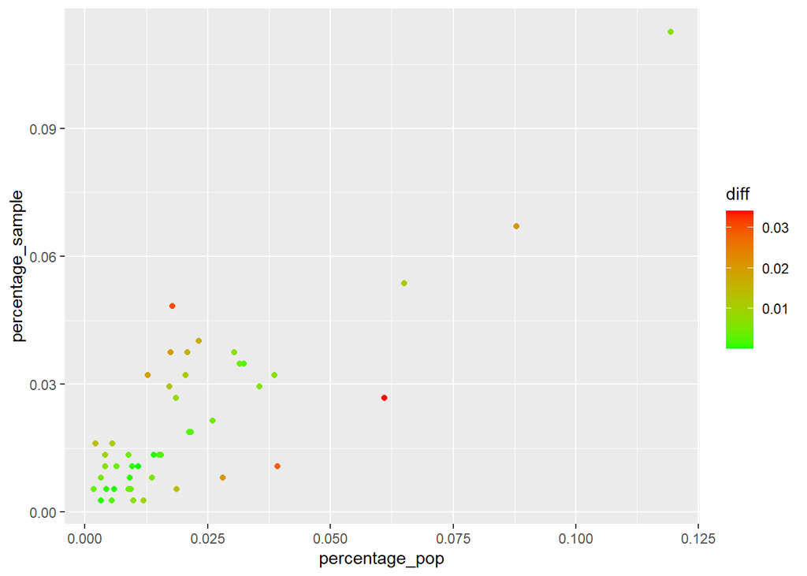

How predictive is your inability to do any one of these predictive to do all of them. Is it our same chunk of people that are not able to do these or is it all over the place.

1. ORE for Publicly Owned Animals Q20
2. Spay Neuter for Publicly Owned Animals Q20
3. Community Vaccination Clinics Q20
4. Intake Prevention and Vet Services Q27
5. Org Takes in Stray/Outdoor Cats Q36
6. Percentage Stray/Outdoor Steralized and Returned Q39
7. Community Cat Spay Neuter Program Q29

How I answered this question by creating a 1 0 column for each of the questions above that if an org offered the service pretty regularly, then they got a 1. If not, then they got a 0. My thought behind this was that if we see a spike of 0, 1s, and 2s, that would mean its the same chunk of people not being able to provide the services. If we see pretty similar numbers across the board, then the services provided by shelters is all over the place.

From the graph below, it seems that it isn’t our same chunk of people not able to provide services. It may be interesting to see if certain services are predictive of whether or not a shelter would provide another service.

Let me know if you have a different idea on how to answer this question.

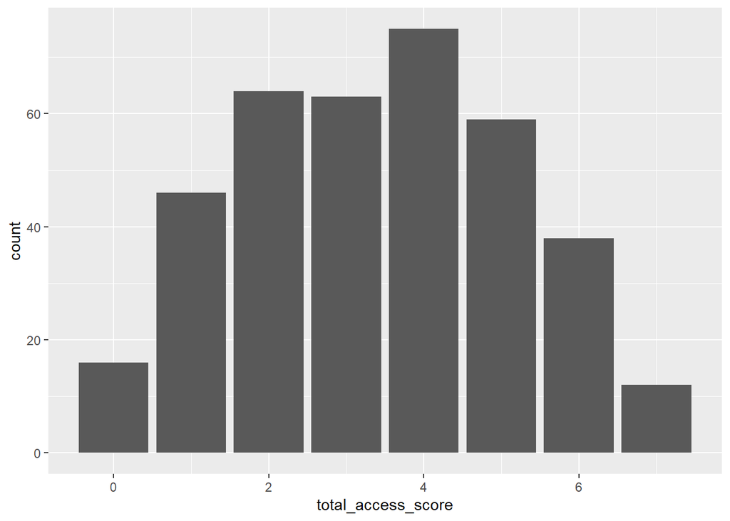

### Breakdown of Org Types

|  | Q4_Org_Type | Count | Percent |
| --- | --- | --- | --- |
| 1 | Brick-and-mortar government animal shelter | 104 | 22.32 |
| 2 | Brick-and-mortar nonprofit animal shelter WITH a government contract for animal control or housing services | 122 | 26.18 |
| 3 | Brick-and-mortar nonprofit animal shelter WITHOUT a government contract for animal control or housing services | 147 | 31.55 |
| 4 | Foster-based animal rescue organization WITH a government contract for animal control and/or sheltering services | 1 | 0.21 |
| 5 | Foster-based animal rescue organization WITHOUT a government contract for animal control and/or sheltering services | 50 | 10.73 |
| 6 | Other | 28 | 6.01 |
| 7 | Spay/neuter clinic | 14 | 3 |

|  | Q4_Org_Type | Count | Percent |
| --- | --- | --- | --- |
| 1 | Gov Shelter | 104 | 27.88 |
| 2 | Non-Profit WITH | 122 | 32.71 |
| 3 | Non-Profit WO | 147 | 39.41 |

```
## [1] "non_metro_orgs"
```

|  | Q4_Org_Type | Count | Percent |
| --- | --- | --- | --- |
| 1 | Gov Shelter | 16 | 24.24 |
| 2 | Non-Profit WITH | 25 | 37.88 |
| 3 | Non-Profit WO | 25 | 37.88 |

### Breakdown of Annual Budget

|  | Q5_Annual_Budget | Count | Percent |
| --- | --- | --- | --- |
| 1 | a &lt; $100,000 | 14 | 3.75 |
| 2 | b $100,000-$499,999 | 66 | 17.69 |
| 3 | c $500,000-$999,999 | 50 | 13.4 |
| 4 | d $1,000,000-$4,999,999 | 154 | 41.29 |
| 5 | e $5,000,000 - $9,999,999 | 37 | 9.92 |
| 6 | f $10,000,000 - $24,999,999 | 33 | 8.85 |
| 7 | g &gt;$25,000,000 | 11 | 2.95 |
| 8 |  | 8 | 2.14 |

|  | condensed_budget | Count | Percent |
| --- | --- | --- | --- |
| 1 | Greater 1M | 235 | 63 |
| 2 | Less 1M | 130 | 34.85 |
| 3 |  | 8 | 2.14 |

### Breakdown Intakes and Outcomes

```
## $range
## [1]     0 56000
##
## $standard_deviation
## [1] 5299.441
```

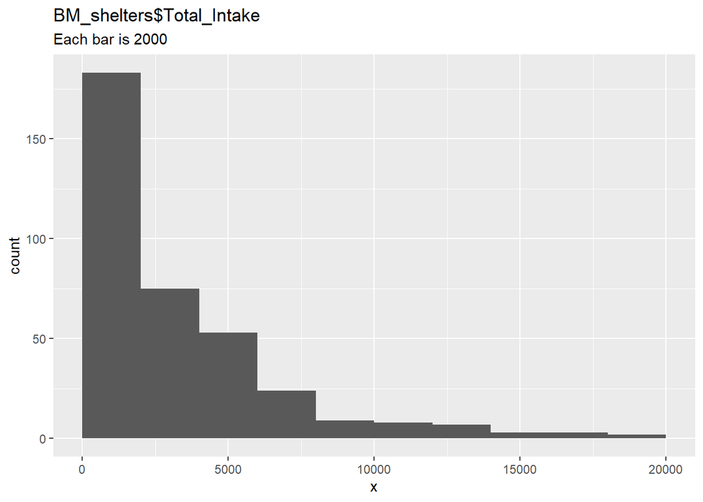

```
## $range
## [1]     0 36000
##
## $standard_deviation
## [1] 4176.642
```

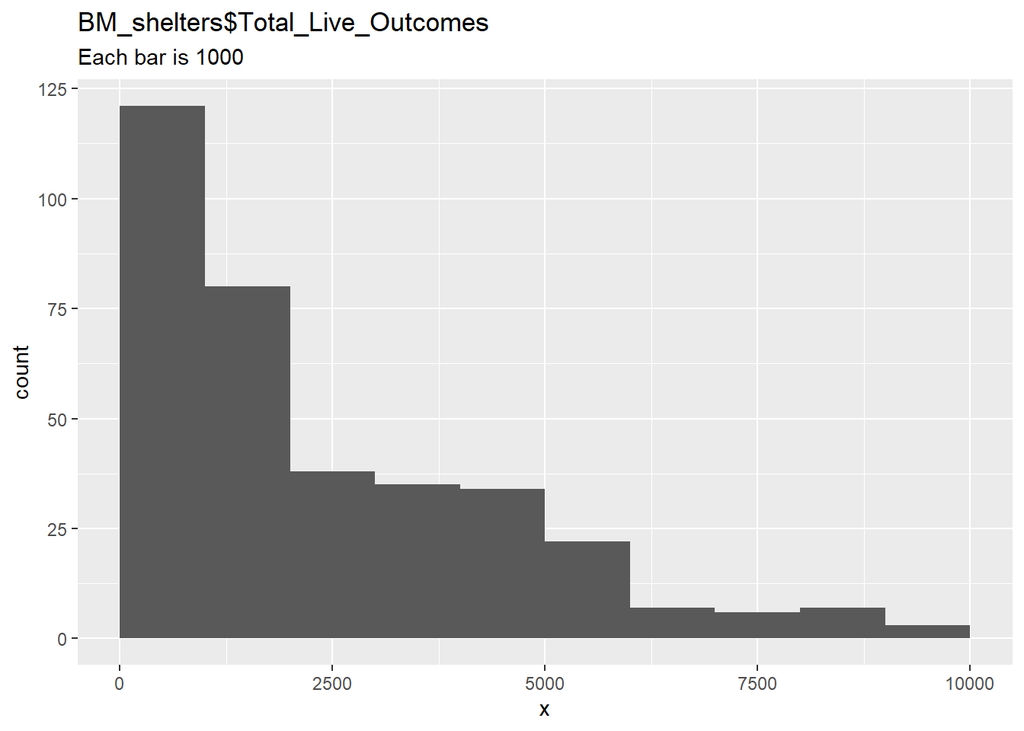

```
## $range
## [1]     0 22000
##
## $standard_deviation
## [1] 1804.153
```

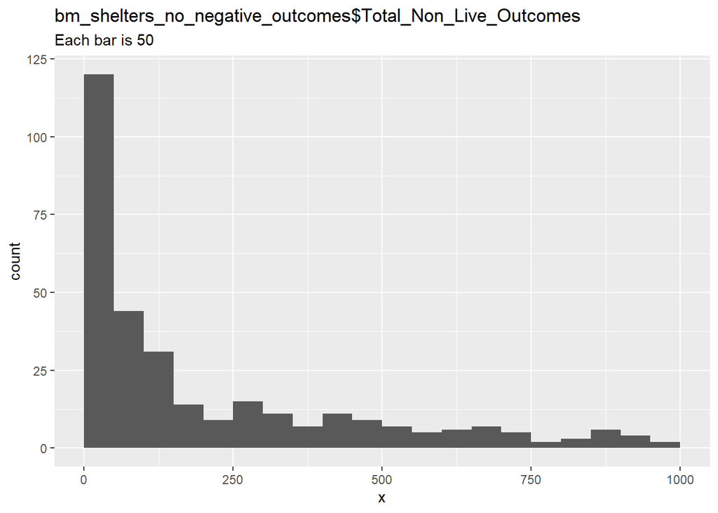

```
## $range
## [1]     0 28000
##
## $standard_deviation
## [1] 2469.667
```

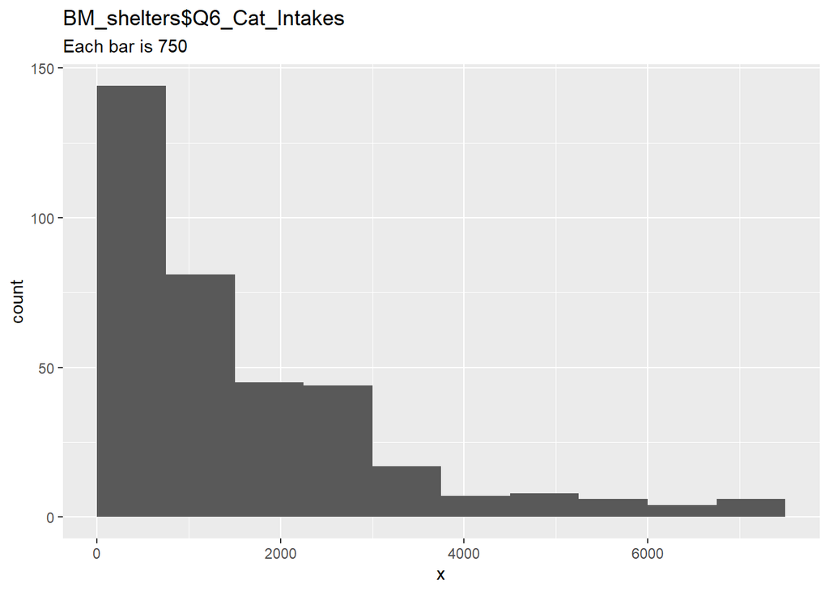

```
## $range
## [1]     0 18000
##
## $standard_deviation
## [1] 1979.46
```

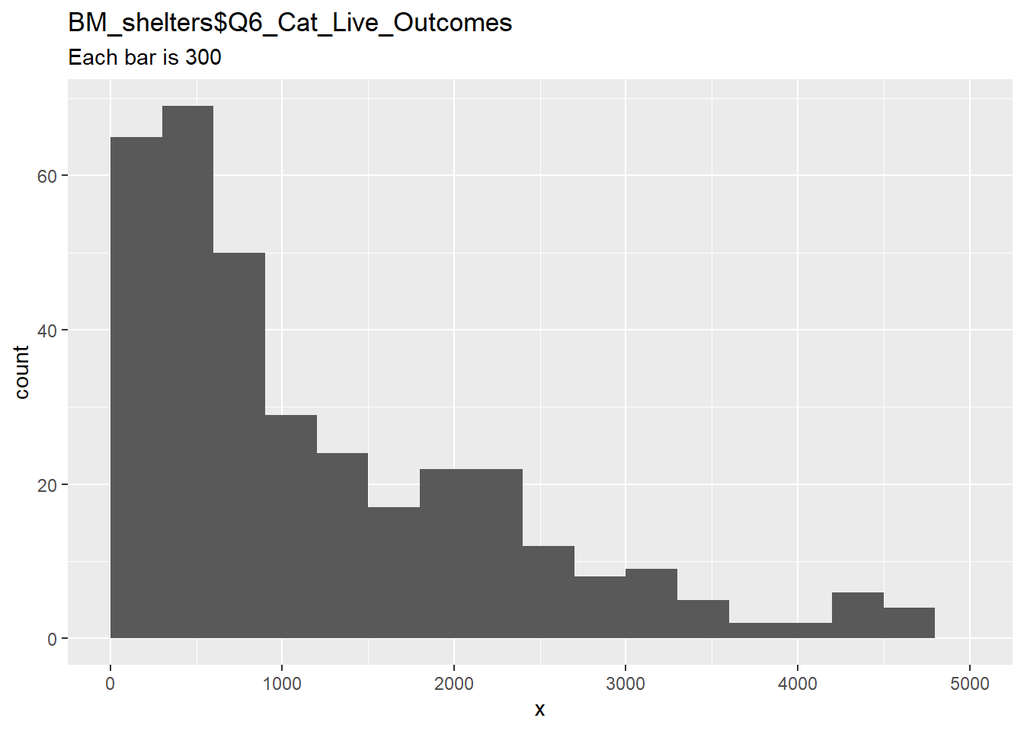

```
## $range
## [1] -1500 10000
##
## $standard_deviation
## [1] 645.2209
```

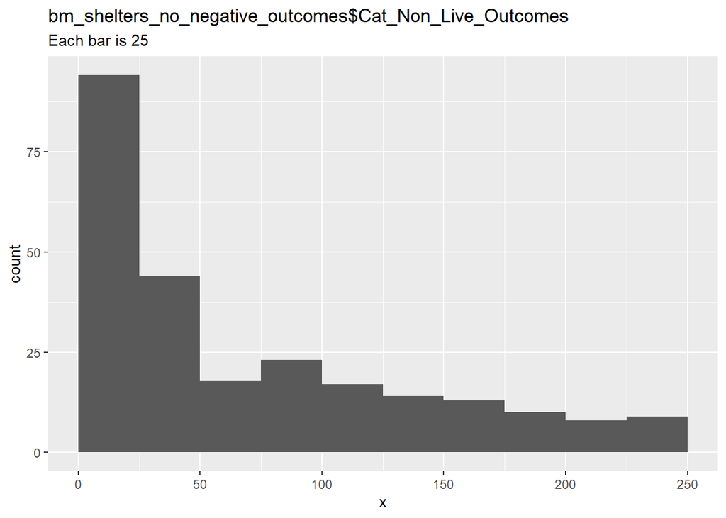

```
## $range
## [1]     0 18468
##
## $standard_deviation
## [1] 2416.061
```

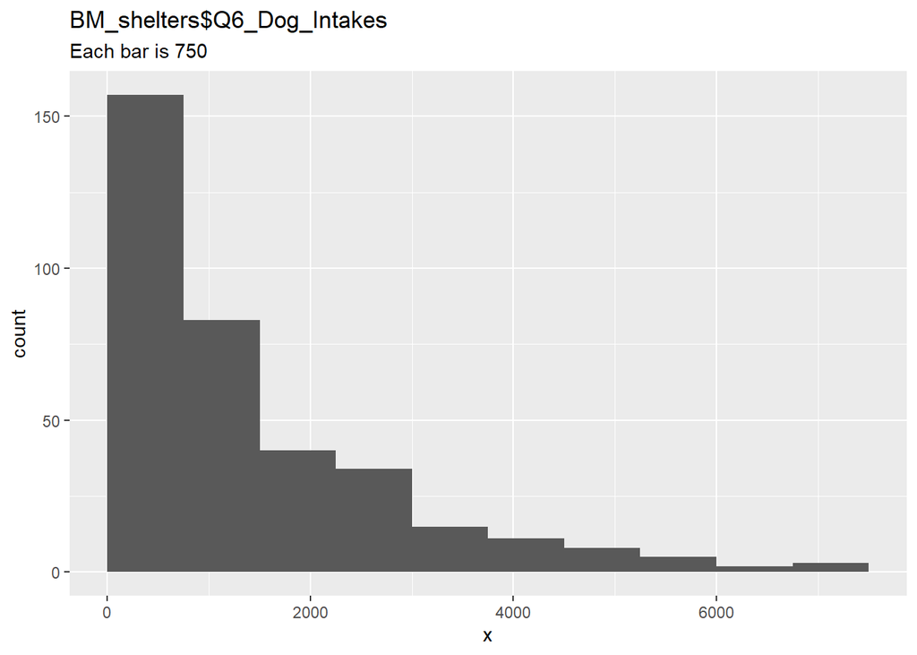

```
## $range
## [1]     0 16181
##
## $standard_deviation
## [1] 1982.332
```

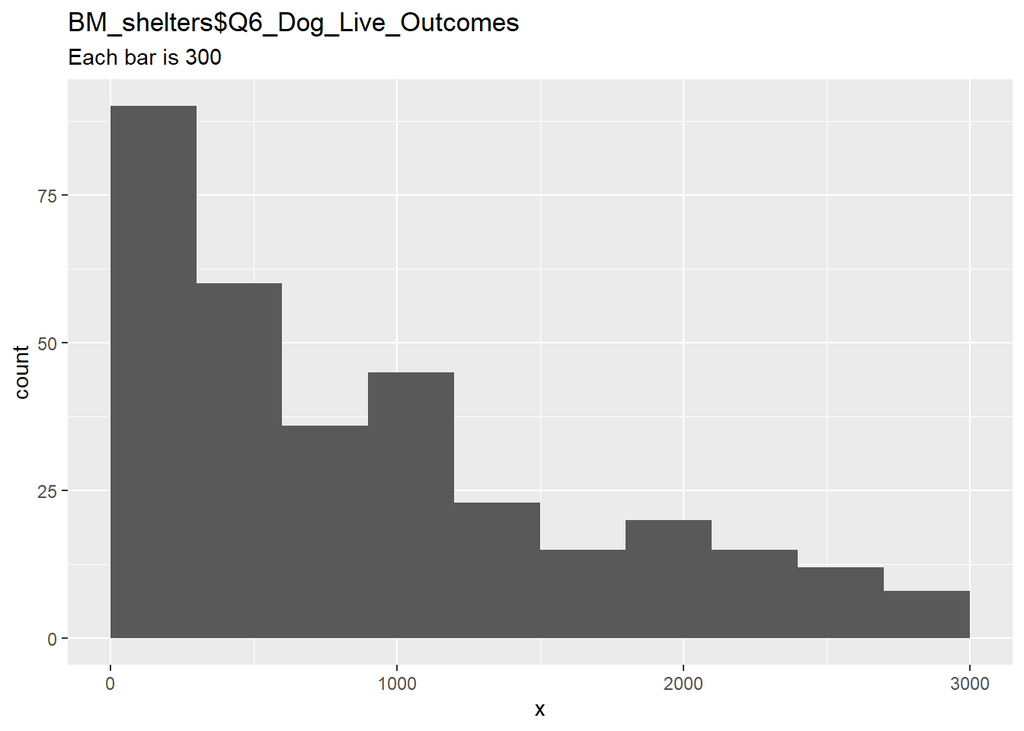

```
## $range
## [1] -241 3289
##
## $standard_deviation
## [1] 404.8056
```

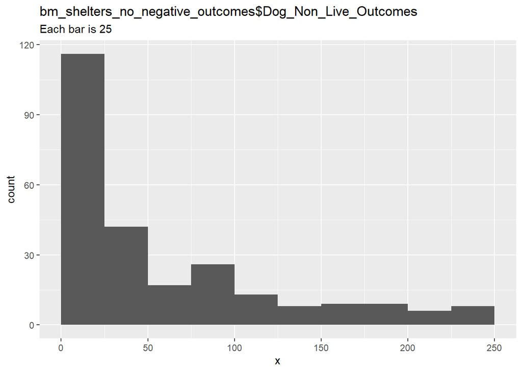

### How many Vet Techs do shelters with vets have

```
## $range
## [1]  0 50
##
## $standard_deviation
## [1] 8.451508
```

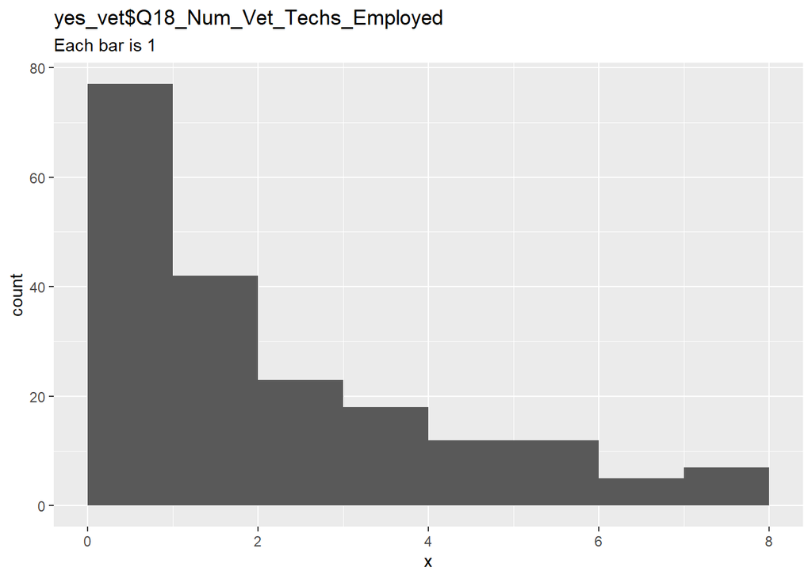

```
##
##    0  0.5    1  1.5    2    3    4  4.5    5    6    7    8    9   10   11   12
##   30    1   46    4   38   23   18    2   10   12    5    7    3    8    6    1
##   14   15   17   19   20   23   24   25   27 27.5   30   33   35   40   45   47
##    5    1    2    1    1    1    1    2    1    1    1    1    1    1    1    2
##   50
##    1
```

```
## $range
## [1]  0 61
##
## $standard_deviation
## [1] 7.184952
```

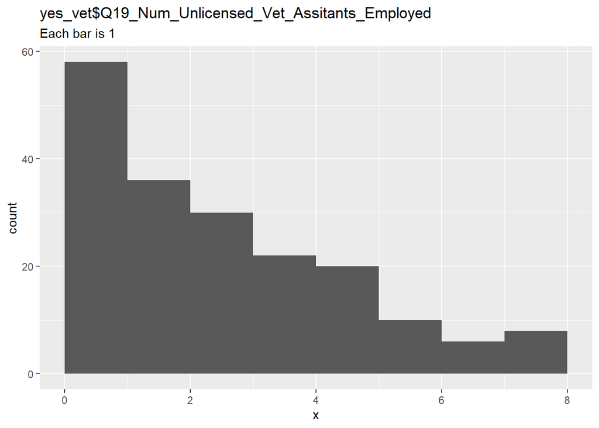

```
##
##     0   0.5     1   1.5     2     3   3.5     4     5     6     7   7.5     8
##    25     1    32     1    35    30     1    21    20    10     6     1     7
##     9   9.8    10    11    12    13    14  14.5    15    16    18    20    23
##     5     1    10     1     3     2     1     1     9     1     2     6     2
## 25.75    40    45    61
##     1     1     1     1
```

### How many Vet Techs do shelters without vets have

A majority of the organizations without a vet don’t have any vet_assistants

```
## $range
## [1] 0 8
##
## $standard_deviation
## [1] 1.209016
```

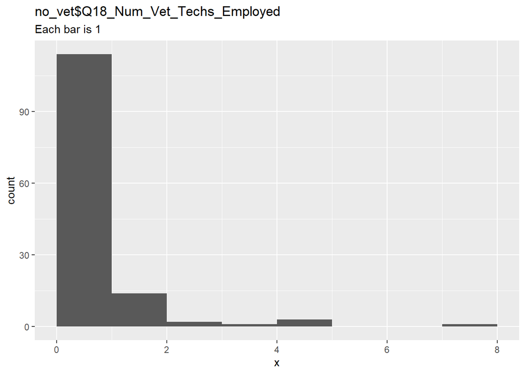

```
##
##   0   1 1.5   2   3   4   5   8
##  82  32   1  13   2   1   3   1
```

```
## $range
## [1]  0 16
##
## $standard_deviation
## [1] 1.766003
```

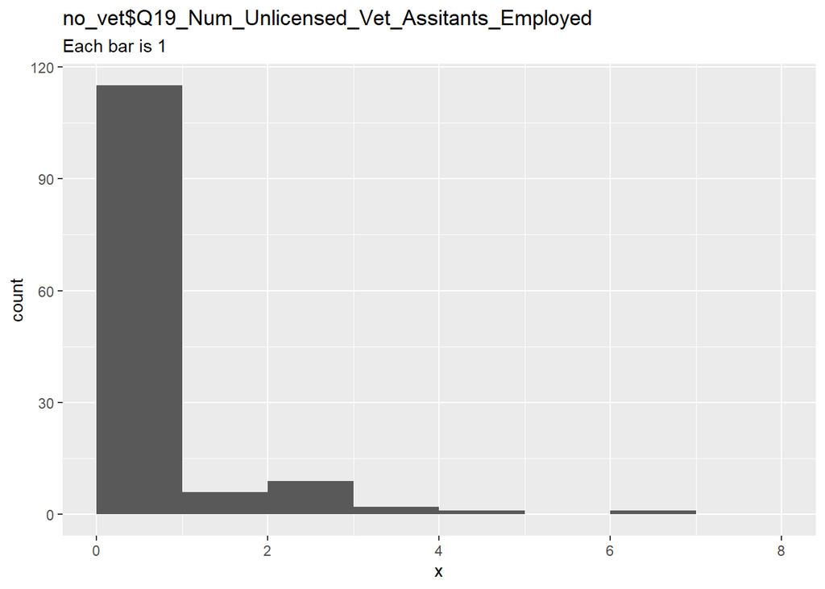

```
##
##   0 0.5   1   2   3   4   5   7  16
##  90   1  24   6   9   2   1   1   1
```

### States Distribution and Region Distribution

|  | state_id | Count |
| --- | --- | --- |
| 1 | AK | 6 |
| 2 | AL | 5 |
| 3 | AR | 3 |
| 4 | AZ | 7 |
| 5 | CA | 42 |
| 6 | CO | 14 |
| 7 | CT | 4 |
| 8 | FL | 20 |
| 9 | GA | 13 |
| 10 | HI | 2 |

[output cut: 36 more lines]

|  | sheltering_region | Count |
| --- | --- | --- |
| 1 | East North Central | 67 |
| 2 | East South Central | 24 |
| 3 | Middle Atlantic | 17 |
| 4 | Mountain | 39 |
| 5 | New England | 21 |
| 6 | Pacific | 77 |
| 7 | South Atlantic | 62 |
| 8 | West North Central | 32 |
| 9 | West South Central | 34 |

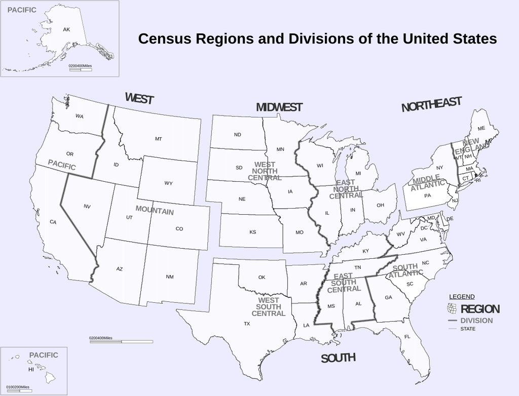

US Census/SAC Regions

### Distribution of RUCC

|  | RUCC_2023 | Count |
| --- | --- | --- |
| 1 | 1 | 170 |
| 2 | 2 | 94 |
| 3 | 3 | 43 |
| 4 | 4 | 20 |
| 5 | 5 | 7 |
| 6 | 6 | 16 |
| 7 | 7 | 10 |
| 8 | 8 | 6 |
| 9 | 9 | 7 |

|  | RUCC_Condensed | Count |
| --- | --- | --- |
| 1 | Metro | 307 |
| 2 | Non-Metro | 66 |

### What are the range of services provided? Most regural to most complex

Rank of Services

1. ORE for Publicly Owned Animals Q20
2. Spay Neuter for Publicly Owned Animals Q20
3. Community Vaccination Clinics Q20
4. Intake Prevention and Vet Services Q27
5. Org Takes in Stray/Outdoor Cats Q36
6. Percentage Stray/Outdoor Steralized and Returned Q39
7. Community Cat Spay Neuter Program Q29
8. Level of Agreement with Cat Sterilization Statement Q41

### Services Break Down

```
## [1] "ORE For Public Owned Animals Count and Prop"
```

```
##
##  No Yes
## 168 205
```

```
##
##        No       Yes
## 0.4504021 0.5495979
```

```
## [1] "Spay Neuter for Publicly Owned Animals"
```

```
##
##  No Yes
## 171 202
```

```
##
##       No      Yes
## 0.458445 0.541555
```

```
## [1] "Provides Community Vaccination Clinics"
```

```
##
##  No Yes
## 155 218
```

```
##
##        No       Yes
## 0.4155496 0.5844504
```

```
## [1] "Intake Prevention and Vet Services"
```

```
##
## Consitently/Often      Never/Rarely         Sometimes
##               113               156               104
```

```
##
## Consitently/Often      Never/Rarely         Sometimes
##         0.3029491         0.4182306         0.2788204
```

```
## [1] "Takes in Stray and Outdoor Cats"
```

```
##
##  No Yes
##  72 301
```

[output not shown]

```
## [1] "Stray/Outdoor Cat Sterilized and Returned"
```

```
##
##   1% - 25%  26% - 50%  51% - 75% 76% - 100%   Not sure
##        104         29         13         43         13
```

```
##
##   1% - 25%  26% - 50%  51% - 75% 76% - 100%   Not sure
## 0.51485149 0.14356436 0.06435644 0.21287129 0.06435644
```

```
## [1] "Community Cat Spay Neuter Programs"
```

```
##
## Consitently/Often      Never/Rarely         Sometimes
##               175               113                85
```

```
##
## Consitently/Often      Never/Rarely         Sometimes
##         0.4691689         0.3029491         0.2278820
```

```
## [1] "Agreement with Cat Sterilization Statement"
```

```
## [1] "Ideally, our organization would like to be able to sterilize a greater proportion of stray/community cats and return them to where they were found."
```

```
##
##           Neither    Somewhat agree Somewhat disagree    Strongly agree
##                55                70                21               192
## Strongly disagree
##                35
```

```
##
##           Neither    Somewhat agree Somewhat disagree    Strongly agree
##        0.14745308        0.18766756        0.05630027        0.51474531
## Strongly disagree
##        0.09383378
```

ORE

```
## [1] "ORE Public Owned Animals"
```

```
##
##  No Yes
## 168 205
```

```
## [1] "Organization Type"
```

```
##
##     Gov Shelter Non-Profit WITH   Non-Profit WO
##             104             122             147
```

```
## [1] "ORE Public Owned Animals/Organization Type"
```

```
##
##       Gov Shelter Non-Profit WITH Non-Profit WO
##   No           35              39            94
##   Yes          69              83            53
```

```
## # A tibble: 1 x 4
##   Service                                    P_Value Cramer_V Count
##   <chr>                                        <dbl>    <dbl> <int>
## 1 ORE Public Owned Animals and Org Type 0.0000000239    0.307   373
```

```
## [1] "ORE Public Owned Animals/Annual Budget"
```

```
##
##       a < $100,000 b $100,000-$499,999 c $500,000-$999,999
##   No             9                  49                  28
##   Yes            5                  17                  22
##
##       d $1,000,000-$4,999,999 e $5,000,000 - $9,999,999
##   No                       61                         9
##   Yes                      93                        28
##
##       f $10,000,000 - $24,999,999 g >$25,000,000
##   No                            8              2
##   Yes                          25              9
```

```
## # A tibble: 1 x 4
##   Service                                         P_Value Cramer_V Count
##   <chr>                                             <dbl>    <dbl> <int>
## 1 ORE Public Owned Animals and Annual Budget 0.0000000623    0.349   373
```

```
## [1] "ORE Public Owned Animals/Condensed Budget"
```

```
##
##       Greater 1M Less 1M
##   No          80      86
##   Yes        155      44
```

```
## # A tibble: 1 x 4
##   Service                                             P_Value Cramer_V Count
##   <chr>                                                 <dbl>    <dbl> <int>
## 1 ORE Public Owned Animals and Condensed Budget 0.00000000704    0.309   373
```

```
## [1] "ORE Public Owned Animals/RUCC Condensed"
```

```
##
##       Metro Non-Metro
##   No    131        37
##   Yes   176        29
```

```
## # A tibble: 1 x 4
##   Service                                     P_Value Cramer_V Count
##   <chr>                                         <dbl>    <dbl> <int>
## 1 ORE Public Owned Animals and RUCC Condensed  0.0647    0.103   373
```

```
## [1] "ORE public Owned Animals/RUCC All"
```

```
##
##         1   2   3   4   5   6   7   8   9
##   No   67  42  22   9   2   9   6   5   6
##   Yes 103  52  21  11   5   7   4   1   1
```

```
## # A tibble: 1 x 4
##   Service                               P_Value Cramer_V Count
##   <chr>                                   <dbl>    <dbl> <int>
## 1 ORE Public Owned Animals and RUCC All  0.0943    0.191   373
```

```
## [1] "ORE Public Owned Animals/Vet on Staff"
```

```
##             Vet on Staff
## Provides ORE  No Yes
##          No   94  74
##          Yes  41 164
```

```
## # A tibble: 1 x 4
##   Service                                    P_Value Cramer_V Count
##   <chr>                                        <dbl>    <dbl> <int>
## 1 ORE Public Owned Animals and Vet on Staff 1.44e-12    0.372   373
```

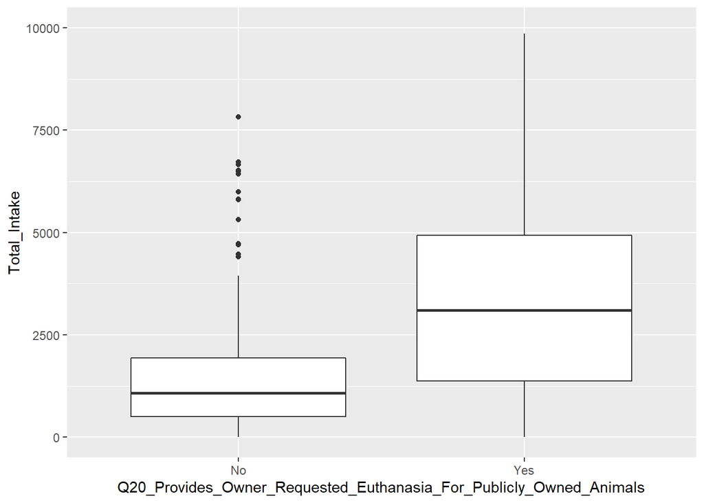

```
##
## Call:
## glm(formula = Q20_Provides_Owner_Requested_Euthanasia_For_Publicly_Owned_Animals ~
##     Total_Intake, family = binomial, data = clean_Log_bm_shelters)
##
## Deviance Residuals:
##     Min       1Q   Median       3Q      Max
## -2.3249  -1.0047   0.3725   1.0654   1.5058
##
## Coefficients:
##                Estimate Std. Error z value Pr(>|z|)
## (Intercept)  -0.7461192  0.1687921   -4.42 9.85e-06 ***
## Total_Intake  0.0003252  0.0000495    6.57 5.02e-11 ***
## ---
## Signif. codes:  0 '***' 0.001 '**' 0.01 '*' 0.05 '.' 0.1 ' ' 1
##
## (Dispersion parameter for binomial family taken to be 1)
##
##     Null deviance: 513.41  on 372  degrees of freedom
## Residual deviance: 453.95  on 371  degrees of freedom
## AIC: 457.95
##
## Number of Fisher Scoring iterations: 4
```

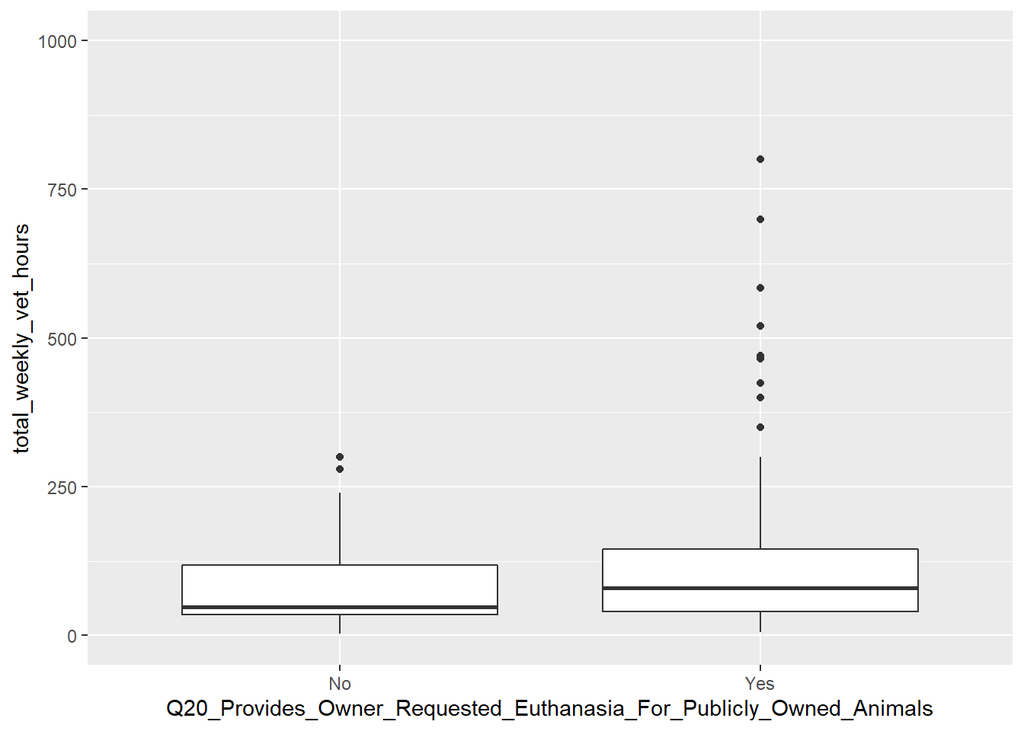

```
##
## Call:
## glm(formula = Q20_Provides_Owner_Requested_Euthanasia_For_Publicly_Owned_Animals ~
##     total_weekly_vet_hours, family = binomial, data = yes_vet_clean_log)
##
## Deviance Residuals:
##     Min       1Q   Median       3Q      Max
## -1.9097  -1.3987   0.8086   0.9416   1.0125
##
## Coefficients:
##                        Estimate Std. Error z value Pr(>|z|)
## (Intercept)            0.379903   0.205467   1.849   0.0645 .
## total_weekly_vet_hours 0.004225   0.001737   2.433   0.0150 *
## ---
## Signif. codes:  0 '***' 0.001 '**' 0.01 '*' 0.05 '.' 0.1 ' ' 1
##
## (Dispersion parameter for binomial family taken to be 1)
##
##     Null deviance: 295.04  on 237  degrees of freedom
## Residual deviance: 285.89  on 236  degrees of freedom
## AIC: 289.89
##
## Number of Fisher Scoring iterations: 6
```

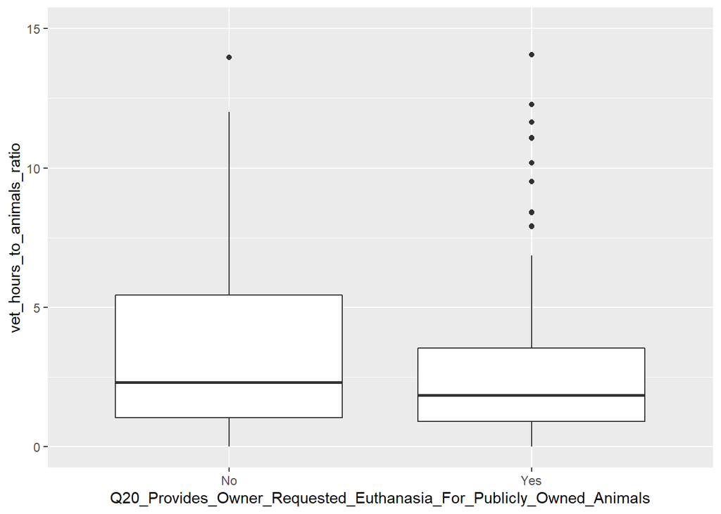

```
##
## Call:
## glm(formula = Q20_Provides_Owner_Requested_Euthanasia_For_Publicly_Owned_Animals ~
##     vet_hours_to_animals_ratio, family = binomial, data = yes_vet_clean_log)
##
## Deviance Residuals:
##     Min       1Q   Median       3Q      Max
## -1.6227  -1.5205   0.8651   0.8685   0.8706
##
## Coefficients:
##                            Estimate Std. Error z value Pr(>|z|)
## (Intercept)                0.774844   0.146886   5.275 1.33e-07 ***
## vet_hours_to_animals_ratio 0.004281   0.009700   0.441    0.659
## ---
## Signif. codes:  0 '***' 0.001 '**' 0.01 '*' 0.05 '.' 0.1 ' ' 1
##
## (Dispersion parameter for binomial family taken to be 1)
##
##     Null deviance: 295.04  on 237  degrees of freedom
## Residual deviance: 294.79  on 236  degrees of freedom
## AIC: 298.79
##
## Number of Fisher Scoring iterations: 4
```

Spay Neuter for Publicly Owned Animals

```
##
##       Gov Shelter Non-Profit WITH Non-Profit WO
##   No    0.7211538       0.3278689     0.3809524
##   Yes   0.2788462       0.6721311     0.6190476
```

```
## # A tibble: 1 x 4
##   Service                                P_Value Cramer_V Count
##   <chr>                                    <dbl>    <dbl> <int>
## 1 Spay Neuter Public Owned Animals 0.00000000135    0.331   373
```

```
##
##           Metro Non-Metro
##   No  0.4299674 0.5909091
##   Yes 0.5700326 0.4090909
```

```
## # A tibble: 1 x 4
##   Service                          P_Value Cramer_V Count
##   <chr>                              <dbl>    <dbl> <int>
## 1 Spay Neuter Public Owned Animals  0.0248    0.123   373
```

```
##
##       Greater 1M   Less 1M
##   No   0.3404255 0.6692308
##   Yes  0.6595745 0.3307692
```

```
## # A tibble: 1 x 4
##   Service                                P_Value Cramer_V Count
##   <chr>                                    <dbl>    <dbl> <int>
## 1 Spay Neuter Public Owned Animals 0.00000000306    0.316   373
```

```
##            Vet on Staff
## Spay Neuter  No Yes
##         No   97  74
##         Yes  38 164
```

```
## # A tibble: 1 x 4
##   Service                           P_Value Cramer_V Count
##   <chr>                               <dbl>    <dbl> <int>
## 1 Spay Neuter Public Owned Animals 7.21e-14    0.393   373
```

```
##
##       2000-5000  450-2000 Less than 450 More than 5000
##   No  0.3679245 0.4818182     0.6712329      0.3571429
##   Yes 0.6320755 0.5181818     0.3287671      0.6428571
```

```
## # A tibble: 1 x 4
##   Service                           P_Value Cramer_V Count
##   <chr>                               <dbl>    <dbl> <int>
## 1 Spay Neuter Public Owned Animals 0.000132    0.235   373
```

```
##
##       Metro Non-Metro
##   No    132        39
##   Yes   175        27
```

```
##
##                    No       Yes
##   Metro     0.4299674 0.5700326
##   Non-Metro 0.5909091 0.4090909
```

```
## # A tibble: 1 x 4
##   Service                          P_Value Cramer_V Count
##   <chr>                              <dbl>    <dbl> <int>
## 1 Spay Neuter Public Owned Animals  0.0248    0.123   373
```

```
##
##        1  2  3  4  5  6  7  8  9
##   No  77 40 15  9  4 12  7  4  3
##   Yes 93 54 28 11  3  4  3  2  4
```

```
##
##            No       Yes
##   1 0.4529412 0.5470588
##   2 0.4255319 0.5744681
##   3 0.3488372 0.6511628
##   4 0.4500000 0.5500000
##   5 0.5714286 0.4285714
##   6 0.7500000 0.2500000
##   7 0.7000000 0.3000000
##   8 0.6666667 0.3333333
##   9 0.4285714 0.5714286
```

```
## # A tibble: 1 x 4
##   Service                          P_Value Cramer_V Count
##   <chr>                              <dbl>    <dbl> <int>
## 1 Spay Neuter Public Owned Animals   0.161    0.178   373
```

```
##
##        No Yes
##   No   97  74
##   Yes  38 164
```

```
##                       Vet on Staff
## Provides Sterilization        No       Yes
##                    No  0.5672515 0.4327485
##                    Yes 0.1881188 0.8118812
```

```
## # A tibble: 1 x 4
##   Service                           P_Value Cramer_V Count
##   <chr>                               <dbl>    <dbl> <int>
## 1 Spay Neuter Public Owned Animals 7.21e-14    0.393   373
```

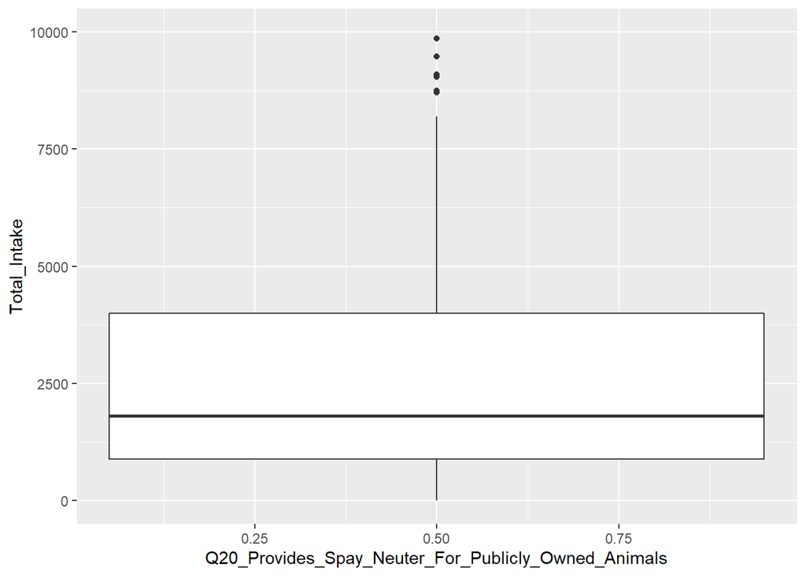

```
##
## Call:
## glm(formula = Q20_Provides_Spay_Neuter_For_Publicly_Owned_Animals ~
##     Total_Intake, family = binomial, data = clean_Log_bm_shelters)
##
## Deviance Residuals:
##     Min       1Q   Median       3Q      Max
## -1.5891  -1.1620   0.8284   1.1304   1.2484
##
## Coefficients:
##                Estimate Std. Error z value Pr(>|z|)
## (Intercept)  -1.654e-01  1.543e-01  -1.072  0.28385
## Total_Intake  1.054e-04  3.689e-05   2.857  0.00427 **
## ---
## Signif. codes:  0 '***' 0.001 '**' 0.01 '*' 0.05 '.' 0.1 ' ' 1
##
## (Dispersion parameter for binomial family taken to be 1)
##
##     Null deviance: 514.51  on 372  degrees of freedom
## Residual deviance: 505.93  on 371  degrees of freedom
## AIC: 509.93
##
## Number of Fisher Scoring iterations: 4
```

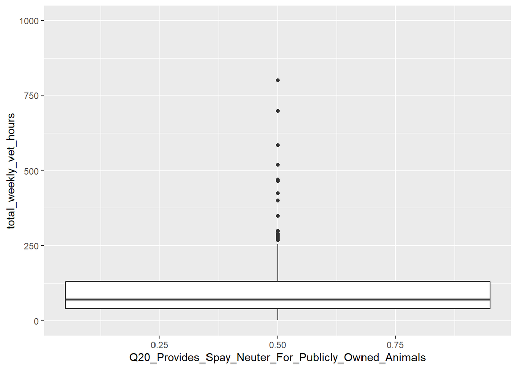

```
##
## Call:
## glm(formula = Q20_Provides_Spay_Neuter_For_Publicly_Owned_Animals ~
##     total_weekly_vet_hours, family = binomial, data = yes_vet_clean_log)
##
## Deviance Residuals:
##     Min       1Q   Median       3Q      Max
## -2.3771  -1.1872   0.5615   0.9262   1.2477
##
## Coefficients:
##                         Estimate Std. Error z value Pr(>|z|)
## (Intercept)            -0.226069   0.242535  -0.932    0.351
## total_weekly_vet_hours  0.012459   0.002934   4.246 2.17e-05 ***
## ---
## Signif. codes:  0 '***' 0.001 '**' 0.01 '*' 0.05 '.' 0.1 ' ' 1
##
## (Dispersion parameter for binomial family taken to be 1)
##
##     Null deviance: 295.04  on 237  degrees of freedom
## Residual deviance: 261.66  on 236  degrees of freedom
## AIC: 265.66
##
## Number of Fisher Scoring iterations: 7
```

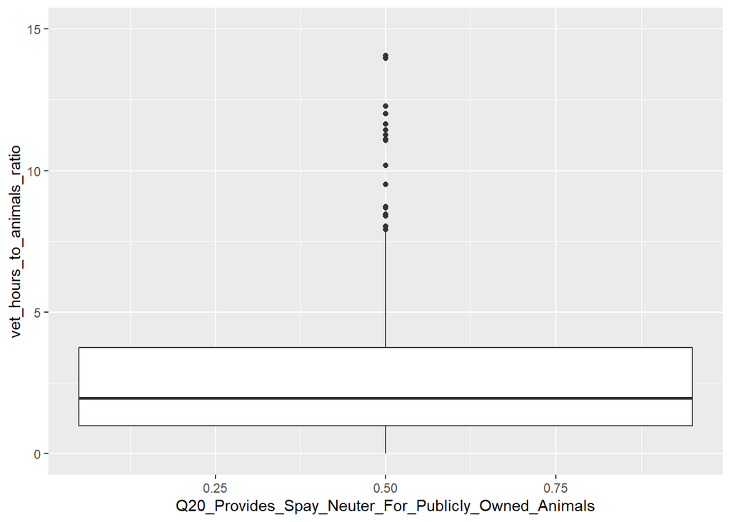

```
##
## Call:
## glm(formula = Q20_Provides_Spay_Neuter_For_Publicly_Owned_Animals ~
##     vet_hours_to_animals_ratio, family = binomial, data = yes_vet_clean_log)
##
## Deviance Residuals:
##     Min       1Q   Median       3Q      Max
## -2.5842  -1.2461   0.6345   0.9432   1.1587
##
## Coefficients:
##                            Estimate Std. Error z value Pr(>|z|)
## (Intercept)                 0.04427    0.21227   0.209  0.83482
## vet_hours_to_animals_ratio  0.27156    0.07131   3.808  0.00014 ***
## ---
## Signif. codes:  0 '***' 0.001 '**' 0.01 '*' 0.05 '.' 0.1 ' ' 1
##
## (Dispersion parameter for binomial family taken to be 1)
##
##     Null deviance: 295.04  on 237  degrees of freedom
## Residual deviance: 268.29  on 236  degrees of freedom
## AIC: 272.29
##
## Number of Fisher Scoring iterations: 7
```

[output not shown]

#### Provides Community Vaccination Clinics

```
##
## col_name Gov Shelter Non-Profit WITH Non-Profit WO
##      No           44              43            68
##      Yes          60              79            79
##
## col_name Gov Shelter Non-Profit WITH Non-Profit WO
##      No    0.4230769       0.3524590     0.4625850
##      Yes   0.5769231       0.6475410     0.5374150
## [1] "Q20_Provides_Community_Vaccination_Clinics"
## # A tibble: 1 x 4
##   Service                                    P_Value Cramer_V Count
##   <chr>                                        <dbl>    <dbl> <int>
## 1 Q20_Provides_Community_Vaccination_Clinics   0.186   0.0950   373
##
## col_name Metro Non-Metro
##      No    117        38
##      Yes   190        28
##
## col_name     Metro Non-Metro
##      No  0.3811075 0.5757576
##      Yes 0.6188925 0.4242424
## # A tibble: 1 x 4
##   Service                                    P_Value Cramer_V Count
##   <chr>                                        <dbl>    <dbl> <int>
## 1 Q20_Provides_Community_Vaccination_Clinics 0.00555    0.151   373
##
## col_name Greater 1M Less 1M
##      No          73      78
##      Yes        162      52
##
## col_name Greater 1M   Less 1M
##      No   0.3106383 0.6000000
##      Yes  0.6893617 0.4000000
## # A tibble: 1 x 4
##   Service                                        P_Value Cramer_V Count
##   <chr>                                            <dbl>    <dbl> <int>
## 1 Q20_Provides_Community_Vaccination_Clinics 0.000000141    0.281   373
##                                           Vet on Staff
## Q20_Provides_Community_Vaccination_Clinics  No Yes
##                                        No   92  63
```

[output cut: 49 more lines]

```
##   Service                                    P_Value Cramer_V Count
##   <chr>                                        <dbl>    <dbl> <int>
## 1 Q20_Provides_Community_Vaccination_Clinics  0.0568    0.201   373
##
## col_name  No Yes
##      No   92  63
##      Yes  43 175
##                                           Vet on Staff
## Q20_Provides_Community_Vaccination_Clinics        No       Yes
##                                        No  0.5935484 0.4064516
##                                        Yes 0.1972477 0.8027523
## # A tibble: 1 x 4
##   Service                                     P_Value Cramer_V Count
##   <chr>                                         <dbl>    <dbl> <int>
## 1 Q20_Provides_Community_Vaccination_Clinics 9.96e-15    0.406   373
```

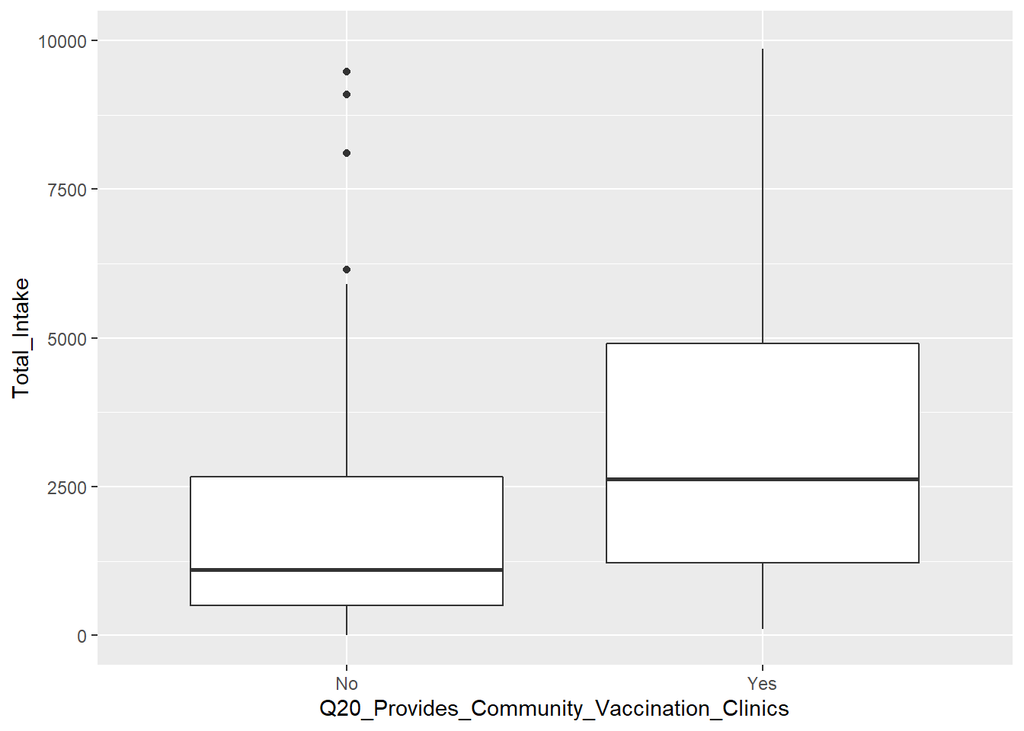

```
##
## Call:
## glm(formula = model_formula, family = binomial, data = clean_Log_bm_shelters)
##
## Deviance Residuals:
##     Min       1Q   Median       3Q      Max
## -2.2564  -1.0786   0.5689   1.0695   1.3720
##
## Coefficients:
##                Estimate Std. Error z value Pr(>|z|)
## (Intercept)  -4.763e-01  1.647e-01  -2.892  0.00383 **
## Total_Intake  2.830e-04  4.801e-05   5.895 3.75e-09 ***
## ---
## Signif. codes:  0 '***' 0.001 '**' 0.01 '*' 0.05 '.' 0.1 ' ' 1
##
## (Dispersion parameter for binomial family taken to be 1)
##
##     Null deviance: 506.40  on 372  degrees of freedom
## Residual deviance: 460.63  on 371  degrees of freedom
## AIC: 464.63
##
## Number of Fisher Scoring iterations: 4
```

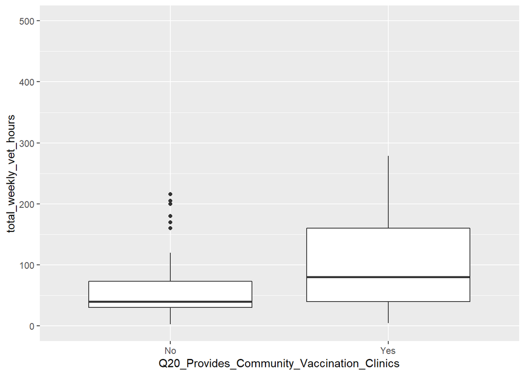

```
##
## Call:
## glm(formula = model_formula, family = binomial, data = yes_vet_clean_log)
##
## Deviance Residuals:
##     Min       1Q   Median       3Q      Max
## -2.2856  -1.2606   0.6299   0.9062   1.1045
##
## Coefficients:
##                        Estimate Std. Error z value Pr(>|z|)
## (Intercept)            0.118015   0.242270   0.487    0.626
## total_weekly_vet_hours 0.011193   0.002825   3.963  7.4e-05 ***
## ---
## Signif. codes:  0 '***' 0.001 '**' 0.01 '*' 0.05 '.' 0.1 ' ' 1
##
## (Dispersion parameter for binomial family taken to be 1)
##
##     Null deviance: 275.09  on 237  degrees of freedom
## Residual deviance: 252.33  on 236  degrees of freedom
## AIC: 256.33
##
## Number of Fisher Scoring iterations: 5
```

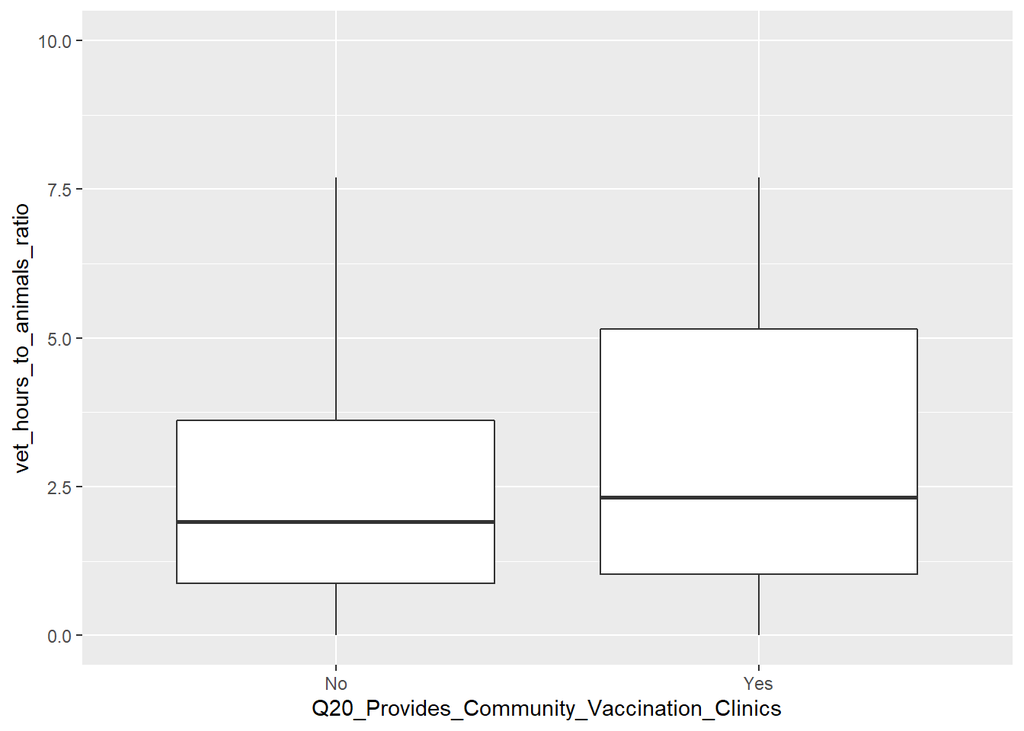

```
##
## Call:
## glm(formula = model_formula, family = binomial, data = yes_vet_clean_log)
##
## Deviance Residuals:
##     Min       1Q   Median       3Q      Max
## -1.7686  -1.5481   0.7691   0.8166   0.8475
##
## Coefficients:
##                            Estimate Std. Error z value Pr(>|z|)
## (Intercept)                 0.83923    0.22360   3.753 0.000175 ***
## vet_hours_to_animals_ratio  0.06362    0.06072   1.048 0.294725
## ---
## Signif. codes:  0 '***' 0.001 '**' 0.01 '*' 0.05 '.' 0.1 ' ' 1
##
## (Dispersion parameter for binomial family taken to be 1)
##
##     Null deviance: 275.09  on 237  degrees of freedom
## Residual deviance: 273.96  on 236  degrees of freedom
## AIC: 277.96
##
## Number of Fisher Scoring iterations: 4
```

#### Intake Prevention and Veterinary Services

```
##
## col_name            Gov Shelter Non-Profit WITH Non-Profit WO
##   Consitently/Often          23              39            51
##   Never/Rarely               54              43            59
##   Sometimes                  27              40            37
##
## col_name            Gov Shelter Non-Profit WITH Non-Profit WO
##   Consitently/Often   0.2211538       0.3196721     0.3469388
##   Never/Rarely        0.5192308       0.3524590     0.4013605
##   Sometimes           0.2596154       0.3278689     0.2517007
## # A tibble: 1 x 4
##   Service                                       P_Value Cramer_V Count
##   <chr>                                           <dbl>    <dbl> <int>
## 1 Q27_Intake_Prevention_and_Veterinary_Services  0.0656    0.109   373
##
## col_name            Metro Non-Metro
##   Consitently/Often   101        12
##   Never/Rarely        124        32
##   Sometimes            82        22
##
## col_name                Metro Non-Metro
##   Consitently/Often 0.3289902 0.1818182
##   Never/Rarely      0.4039088 0.4848485
##   Sometimes         0.2671010 0.3333333
## # A tibble: 1 x 4
##   Service                                       P_Value Cramer_V Count
##   <chr>                                           <dbl>    <dbl> <int>
## 1 Q27_Intake_Prevention_and_Veterinary_Services  0.0611    0.122   373
##
## col_name            Greater 1M Less 1M
##   Consitently/Often         95      16
##   Never/Rarely              84      69
##   Sometimes                 56      45
##
## col_name            Greater 1M   Less 1M
##   Consitently/Often  0.4042553 0.1230769
##   Never/Rarely       0.3574468 0.5307692
##   Sometimes          0.2382979 0.3461538
## # A tibble: 1 x 4
##   Service                                           P_Value Cramer_V Count
```

[output cut: 62 more lines]

```
## 1 Q27_Intake_Prevention_and_Veterinary_Services   0.705    0.130   373
##                                              Vet on Staff
## Q27_Intake_Prevention_and_Veterinary_Services No Yes
##                             Consitently/Often 18  95
##                             Never/Rarely      76  80
##                             Sometimes         41  63
##                                              Vet on Staff
## Q27_Intake_Prevention_and_Veterinary_Services        No       Yes
##                             Consitently/Often 0.1592920 0.8407080
##                             Never/Rarely      0.4871795 0.5128205
##                             Sometimes         0.3942308 0.6057692
## # A tibble: 1 x 4
##   Service                                           P_Value Cramer_V Count
##   <chr>                                               <dbl>    <dbl> <int>
## 1 Q27_Intake_Prevention_and_Veterinary_Services 0.000000171    0.289   373
```

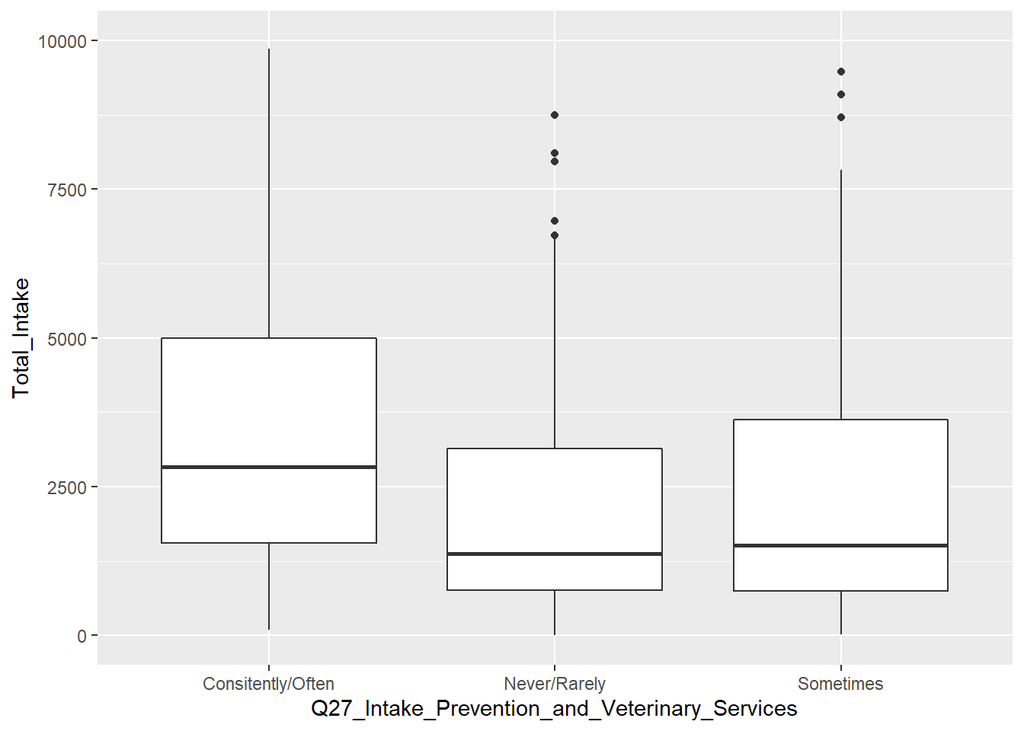

```
## Call:
## multinom(formula = model_formula, data = clean_Log_bm_shelters)
##
## Coefficients:
##              (Intercept)  Total_Intake
## Never/Rarely   0.8164086 -1.489592e-04
## Sometimes      0.2642662 -9.817449e-05
##
## Std. Errors:
##              (Intercept) Total_Intake
## Never/Rarely  0.09839634 3.361266e-05
## Sometimes     0.08396052 3.313436e-05
##
## Residual Deviance: 794.3673
## AIC: 802.3673
```

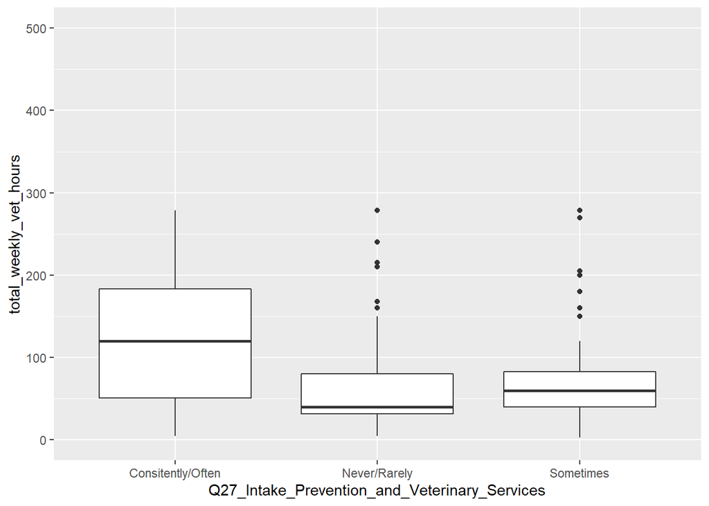

```
## Call:
## multinom(formula = model_formula, data = clean_Log_bm_shelters)
##
## Coefficients:
##              (Intercept) total_weekly_vet_hours
## Never/Rarely   0.9300595           -0.011514896
## Sometimes      0.4579632           -0.008337047
##
## Std. Errors:
##              (Intercept) total_weekly_vet_hours
## Never/Rarely   0.2620930            0.002400781
## Sometimes      0.2728667            0.002255127
##
## Residual Deviance: 481.7621
## AIC: 489.7621
```

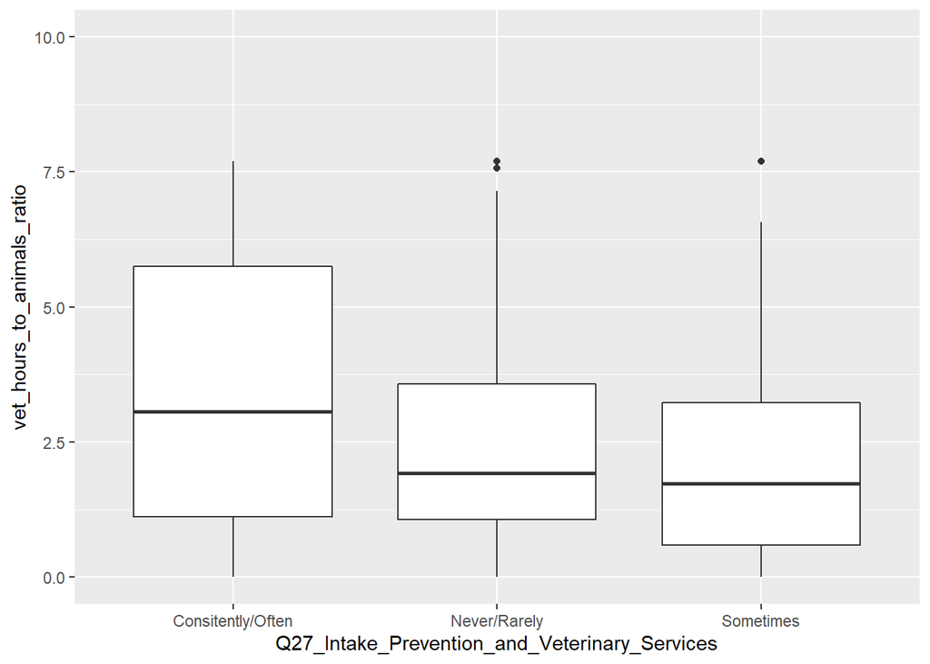

```
## Call:
## multinom(formula = model_formula, data = clean_Log_bm_shelters)
##
## Coefficients:
##              (Intercept) vet_hours_to_animals_ratio
## Never/Rarely   0.8685814                 -0.2501019
## Sometimes      0.4413161                 -0.2319585
##
## Std. Errors:
##              (Intercept) vet_hours_to_animals_ratio
## Never/Rarely   0.1725532                 0.05257056
## Sometimes      0.1865563                 0.05793033
##
## Residual Deviance: 776.6471
## AIC: 784.6471
```

#### Org Takes in Stray/Outdoor Cats

```
##
## col_name Gov Shelter Non-Profit WITH Non-Profit WO
##      No           19               8            45
##      Yes          85             114           102
##
## col_name Gov Shelter Non-Profit WITH Non-Profit WO
##      No   0.18269231      0.06557377    0.30612245
##      Yes  0.81730769      0.93442623    0.69387755
## [1] "Q36_Org_Takes_In_Stray_Outdoor_Cats"
## # A tibble: 1 x 4
##   Service                                P_Value Cramer_V Count
##   <chr>                                    <dbl>    <dbl> <int>
## 1 Q36_Org_Takes_In_Stray_Outdoor_Cats 0.00000399    0.258   373
##
## col_name Metro Non-Metro
##      No     66         6
##      Yes   241        60
##
## col_name      Metro  Non-Metro
##      No  0.21498371 0.09090909
##      Yes 0.78501629 0.90909091
## # A tibble: 1 x 4
##   Service                             P_Value Cramer_V Count
##   <chr>                                 <dbl>    <dbl> <int>
## 1 Q36_Org_Takes_In_Stray_Outdoor_Cats  0.0319    0.120   373
##
## col_name Greater 1M Less 1M
##      No          50      22
##      Yes        185     108
##
## col_name Greater 1M   Less 1M
##      No   0.2127660 0.1692308
##      Yes  0.7872340 0.8307692
## # A tibble: 1 x 4
##   Service                             P_Value Cramer_V Count
##   <chr>                                 <dbl>    <dbl> <int>
## 1 Q36_Org_Takes_In_Stray_Outdoor_Cats   0.388   0.0524   373
##                                    Vet on Staff
## Q36_Org_Takes_In_Stray_Outdoor_Cats  No Yes
##                                 No   24  48
```

[output cut: 49 more lines]

```
##   Service                             P_Value Cramer_V Count
##   <chr>                                 <dbl>    <dbl> <int>
## 1 Q36_Org_Takes_In_Stray_Outdoor_Cats   0.288    0.161   373
##
## col_name  No Yes
##      No   24  48
##      Yes 111 190
##                                    Vet on Staff
## Q36_Org_Takes_In_Stray_Outdoor_Cats        No       Yes
##                                 No  0.3333333 0.6666667
##                                 Yes 0.3687708 0.6312292
## # A tibble: 1 x 4
##   Service                             P_Value Cramer_V Count
##   <chr>                                 <dbl>    <dbl> <int>
## 1 Q36_Org_Takes_In_Stray_Outdoor_Cats   0.670   0.0291   373
```

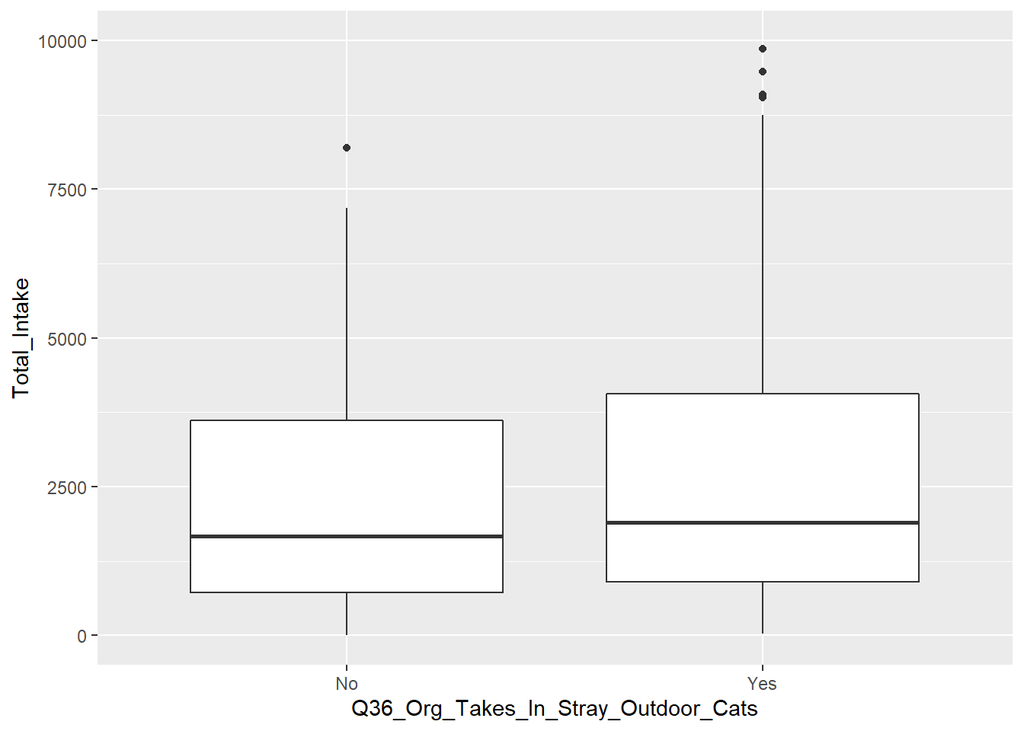

```
##
## Call:
## glm(formula = model_formula, family = binomial, data = clean_Log_bm_shelters)
##
## Deviance Residuals:
##     Min       1Q   Median       3Q      Max
## -2.0637   0.5032   0.6454   0.6986   0.7258
##
## Coefficients:
##               Estimate Std. Error z value Pr(>|z|)
## (Intercept)  1.197e+00  1.896e-01   6.314 2.71e-10 ***
## Total_Intake 7.751e-05  4.865e-05   1.593    0.111
## ---
## Signif. codes:  0 '***' 0.001 '**' 0.01 '*' 0.05 '.' 0.1 ' ' 1
##
## (Dispersion parameter for binomial family taken to be 1)
##
##     Null deviance: 365.98  on 372  degrees of freedom
## Residual deviance: 363.25  on 371  degrees of freedom
## AIC: 367.25
##
## Number of Fisher Scoring iterations: 4
```

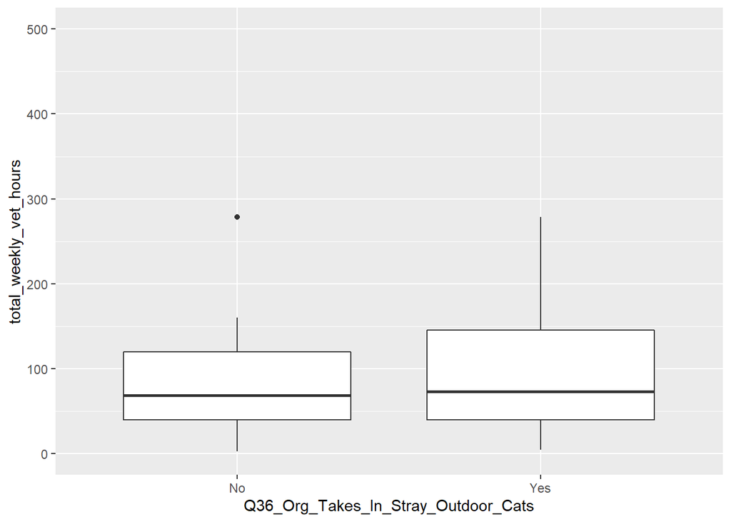

```
##
## Call:
## glm(formula = model_formula, family = binomial, data = yes_vet_clean_log)
##
## Deviance Residuals:
##     Min       1Q   Median       3Q      Max
## -1.9479   0.5701   0.6670   0.7031   0.7245
##
## Coefficients:
##                        Estimate Std. Error z value Pr(>|z|)
## (Intercept)            1.193936   0.249668   4.782 1.73e-06 ***
## total_weekly_vet_hours 0.001940   0.002112   0.918    0.358
## ---
## Signif. codes:  0 '***' 0.001 '**' 0.01 '*' 0.05 '.' 0.1 ' ' 1
##
## (Dispersion parameter for binomial family taken to be 1)
##
##     Null deviance: 239.30  on 237  degrees of freedom
## Residual deviance: 238.42  on 236  degrees of freedom
## AIC: 242.42
##
## Number of Fisher Scoring iterations: 4
```

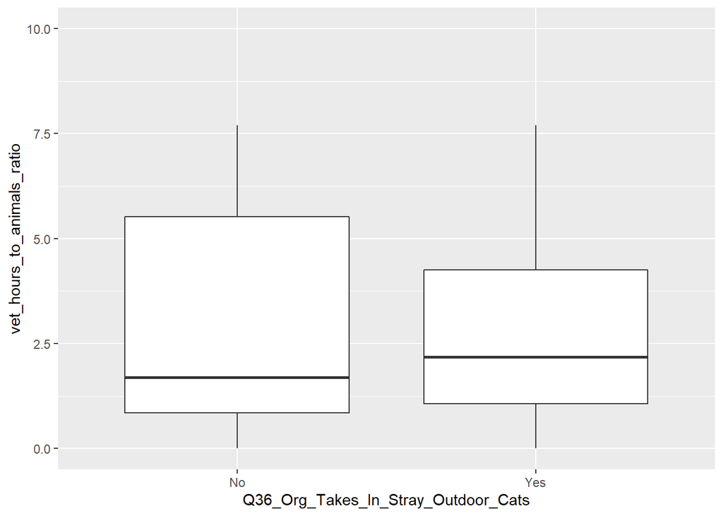

```
##
## Call:
## glm(formula = model_formula, family = binomial, data = yes_vet_clean_log)
##
## Deviance Residuals:
##     Min       1Q   Median       3Q      Max
## -1.8121   0.6561   0.6645   0.6740   0.6955
##
## Coefficients:
##                            Estimate Std. Error z value Pr(>|z|)
## (Intercept)                 1.42661    0.25168   5.668 1.44e-08 ***
## vet_hours_to_animals_ratio -0.01696    0.06376  -0.266     0.79
## ---
## Signif. codes:  0 '***' 0.001 '**' 0.01 '*' 0.05 '.' 0.1 ' ' 1
##
## (Dispersion parameter for binomial family taken to be 1)
##
##     Null deviance: 239.30  on 237  degrees of freedom
## Residual deviance: 239.23  on 236  degrees of freedom
## AIC: 243.23
##
## Number of Fisher Scoring iterations: 4
```

#### Percentage Stray/Outdoor Cat Intakes Sterilized and Returned

```
##
## col_name     Gov Shelter Non-Profit WITH Non-Profit WO
##   1% - 25%            22              44            38
##   26% - 50%            7              19             3
##   51% - 75%            5               5             3
##   76% - 100%          19               8            16
##   Not sure             4               3             6
##
## col_name     Gov Shelter Non-Profit WITH Non-Profit WO
##   1% - 25%    0.38596491      0.55696203    0.57575758
##   26% - 50%   0.12280702      0.24050633    0.04545455
##   51% - 75%   0.08771930      0.06329114    0.04545455
##   76% - 100%  0.33333333      0.10126582    0.24242424
##   Not sure    0.07017544      0.03797468    0.09090909
## # A tibble: 1 x 4
##   Service                                                 P_Value Cramer_V Count
##   <chr>                                                     <dbl>    <dbl> <int>
## 1 Q39_Percentage_Stray_Outdoor_Cat_Intakes_Sterilized_An~ 0.00268    0.242   373
##
## col_name     Metro Non-Metro
##   1% - 25%      86        18
##   26% - 50%     24         5
##   51% - 75%     12         1
##   76% - 100%    36         7
##   Not sure      10         3
##
## col_name          Metro  Non-Metro
##   1% - 25%   0.51190476 0.52941176
##   26% - 50%  0.14285714 0.14705882
##   51% - 75%  0.07142857 0.02941176
##   76% - 100% 0.21428571 0.20588235
##   Not sure   0.05952381 0.08823529
## # A tibble: 1 x 4
##   Service                                                 P_Value Cramer_V Count
##   <chr>                                                     <dbl>    <dbl> <int>
## 1 Q39_Percentage_Stray_Outdoor_Cat_Intakes_Sterilized_An~   0.883   0.0760   373
##
## col_name     Greater 1M Less 1M
##   1% - 25%           63      41
##   26% - 50%          21       7
```

[output cut: 104 more lines]

```
##                                                       26% - 50%  0.2413793
##                                                       51% - 75%  0.3846154
##                                                       76% - 100% 0.2093023
##                                                       Not sure   0.2307692
##                                                                 Vet on Staff
## Q39_Percentage_Stray_Outdoor_Cat_Intakes_Sterilized_And_Returned       Yes
##                                                       1% - 25%   0.6442308
##                                                       26% - 50%  0.7586207
##                                                       51% - 75%  0.6153846
##                                                       76% - 100% 0.7906977
##                                                       Not sure   0.7692308
## # A tibble: 1 x 4
##   Service                                                 P_Value Cramer_V Count
##   <chr>                                                     <dbl>    <dbl> <int>
## 1 Q39_Percentage_Stray_Outdoor_Cat_Intakes_Sterilized_An~   0.352    0.148   373
```

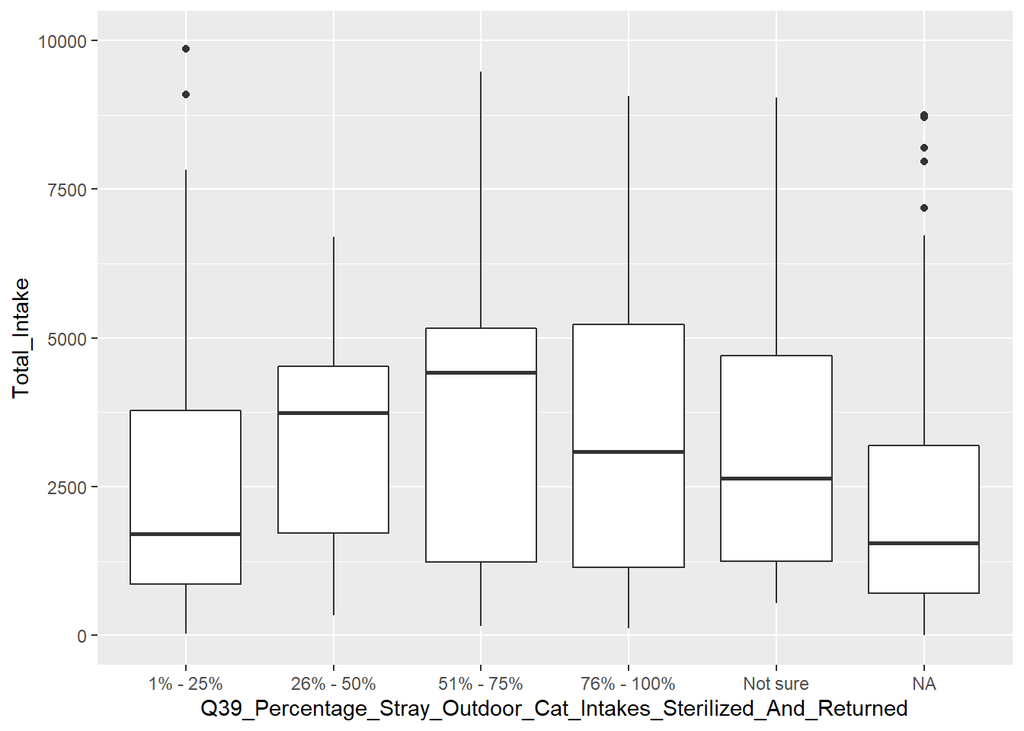

```
## Call:
## multinom(formula = model_formula, data = clean_Log_bm_shelters)
##
## Coefficients:
##            (Intercept) Total_Intake
## 26% - 50%    -1.640588 9.711819e-05
## 51% - 75%    -2.568250 1.254847e-04
## 76% - 100%   -1.137284 7.046976e-05
## Not sure     -2.763739 1.659282e-04
##
## Std. Errors:
##             (Intercept) Total_Intake
## 26% - 50%  6.235538e-09 4.097582e-05
## 51% - 75%  7.563388e-09 5.333921e-05
## 76% - 100% 6.040746e-09 3.720842e-05
## Not sure   6.801773e-09 5.024658e-05
##
## Residual Deviance: 520.1822
## AIC: 536.1822
```

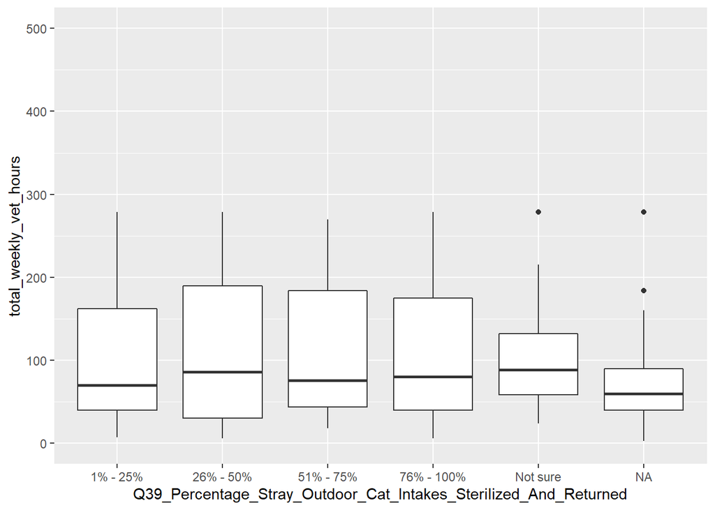

```
## Call:
## multinom(formula = model_formula, data = clean_Log_bm_shelters)
##
## Coefficients:
##            (Intercept) total_weekly_vet_hours
## 26% - 50%   -1.2864787           0.0015749642
## 51% - 75%   -2.3039367           0.0016255424
## 76% - 100%  -0.7508336           0.0006815146
## Not sure    -2.0389546           0.0012603640
##
## Std. Errors:
##            (Intercept) total_weekly_vet_hours
## 26% - 50%    0.4008333            0.002810212
## 51% - 75%    0.6134836            0.004237209
## 76% - 100%   0.3378149            0.002464293
## Not sure     0.5513963            0.003882303
##
## Residual Deviance: 376.5663
## AIC: 392.5663
```

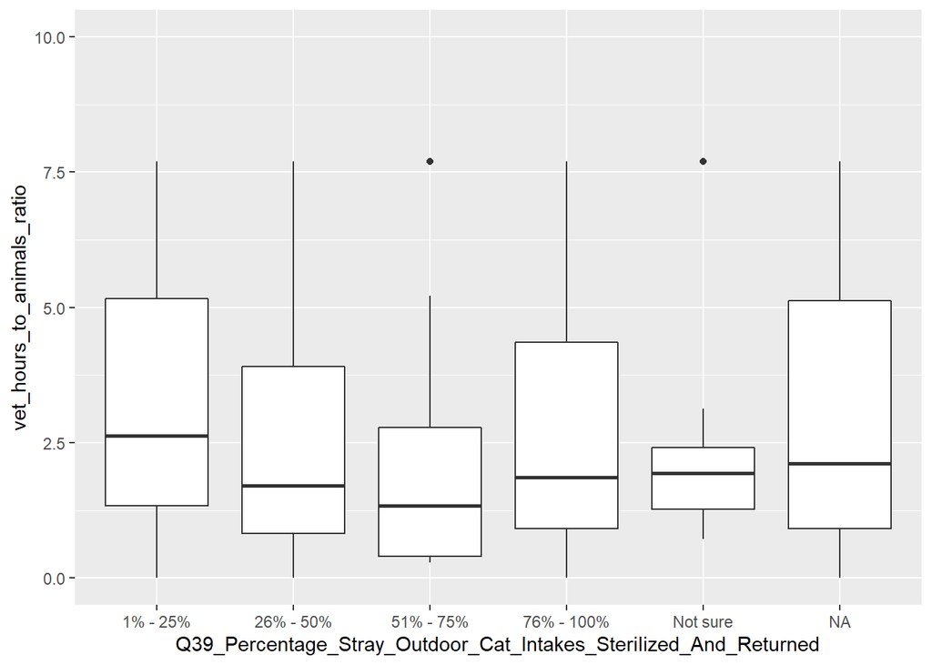

```
## Call:
## multinom(formula = model_formula, data = clean_Log_bm_shelters)
##
## Coefficients:
##            (Intercept) vet_hours_to_animals_ratio
## 26% - 50%   -1.1790824               -0.046646707
## 51% - 75%   -1.9501360               -0.062871329
## 76% - 100%  -0.8943869                0.004966161
## Not sure    -1.9385793               -0.069062163
##
## Std. Errors:
##            (Intercept) vet_hours_to_animals_ratio
## 26% - 50%    0.2776365                 0.08963003
## 51% - 75%    0.3849699                 0.12917479
## 76% - 100%   0.2452665                 0.07311279
## Not sure     0.3839762                 0.13029225
##
## Residual Deviance: 525.6025
## AIC: 541.6025
```

#### Community Cat Spay/Neuter Programs

```
##
## col_name            Gov Shelter Non-Profit WITH Non-Profit WO
##   Consitently/Often          47              67            61
##   Never/Rarely               31              26            56
##   Sometimes                  26              29            30
##
## col_name            Gov Shelter Non-Profit WITH Non-Profit WO
##   Consitently/Often   0.4519231       0.5491803     0.4149660
##   Never/Rarely        0.2980769       0.2131148     0.3809524
##   Sometimes           0.2500000       0.2377049     0.2040816
## # A tibble: 1 x 4
##   Service                                P_Value Cramer_V Count
##   <chr>                                    <dbl>    <dbl> <int>
## 1 Q29_Community_cat_spay_neuter_programs  0.0497    0.113   373
##
## col_name            Metro Non-Metro
##   Consitently/Often   152        23
##   Never/Rarely         82        31
##   Sometimes            73        12
##
## col_name                Metro Non-Metro
##   Consitently/Often 0.4951140 0.3484848
##   Never/Rarely      0.2671010 0.4696970
##   Sometimes         0.2377850 0.1818182
## # A tibble: 1 x 4
##   Service                                P_Value Cramer_V Count
##   <chr>                                    <dbl>    <dbl> <int>
## 1 Q29_Community_cat_spay_neuter_programs 0.00500    0.169   373
##
## col_name            Greater 1M Less 1M
##   Consitently/Often        135      36
##   Never/Rarely              49      63
##   Sometimes                 51      31
##
## col_name            Greater 1M   Less 1M
##   Consitently/Often  0.5744681 0.2769231
##   Never/Rarely       0.2085106 0.4846154
##   Sometimes          0.2170213 0.2384615
## # A tibble: 1 x 4
##   Service                                     P_Value Cramer_V Count
```

[output cut: 62 more lines]

```
## 1 Q29_Community_cat_spay_neuter_programs   0.247    0.161   373
##                                       Vet on Staff
## Q29_Community_cat_spay_neuter_programs  No Yes
##                      Consitently/Often  31 144
##                      Never/Rarely       73  40
##                      Sometimes          31  54
##                                       Vet on Staff
## Q29_Community_cat_spay_neuter_programs        No       Yes
##                      Consitently/Often 0.1771429 0.8228571
##                      Never/Rarely      0.6460177 0.3539823
##                      Sometimes         0.3647059 0.6352941
## # A tibble: 1 x 4
##   Service                                 P_Value Cramer_V Count
##   <chr>                                     <dbl>    <dbl> <int>
## 1 Q29_Community_cat_spay_neuter_programs 6.39e-15    0.419   373
```

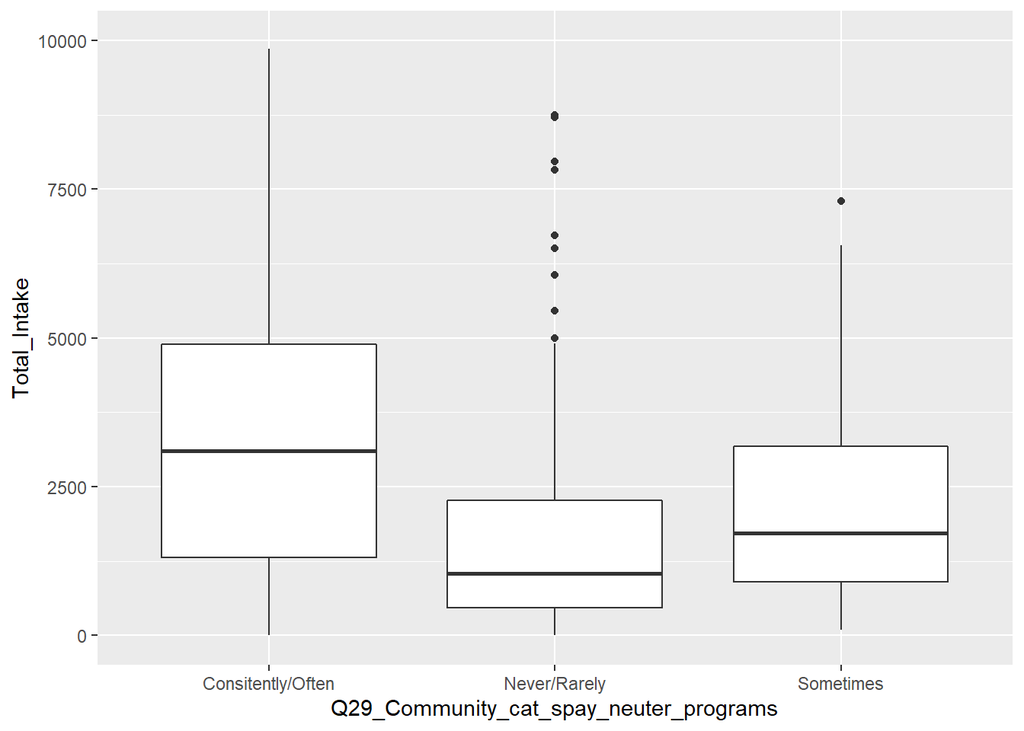

```
## Call:
## multinom(formula = model_formula, data = clean_Log_bm_shelters)
##
## Coefficients:
##              (Intercept)  Total_Intake
## Never/Rarely   0.5401548 -0.0003426649
## Sometimes     -0.1748626 -0.0001570138
##
## Std. Errors:
##              (Intercept) Total_Intake
## Never/Rarely   0.1908366  5.88300e-05
## Sometimes      0.2038211  4.80174e-05
##
## Residual Deviance: 736.506
## AIC: 744.506
```

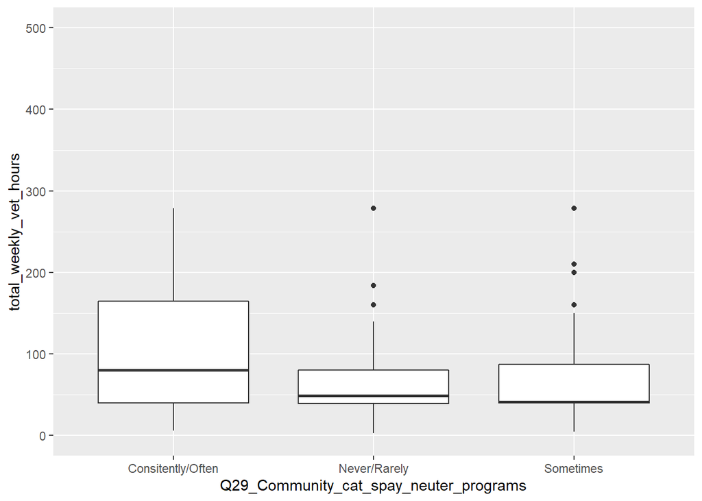

```
## Call:
## multinom(formula = model_formula, data = clean_Log_bm_shelters)
##
## Coefficients:
##              (Intercept) total_weekly_vet_hours
## Never/Rarely  -0.5743839           -0.008045864
## Sometimes     -0.4613822           -0.005505407
##
## Std. Errors:
##              (Intercept) total_weekly_vet_hours
## Never/Rarely   0.2818984            0.002889575
## Sometimes      0.2513604            0.002248723
##
## Residual Deviance: 433.7306
## AIC: 441.7306
```

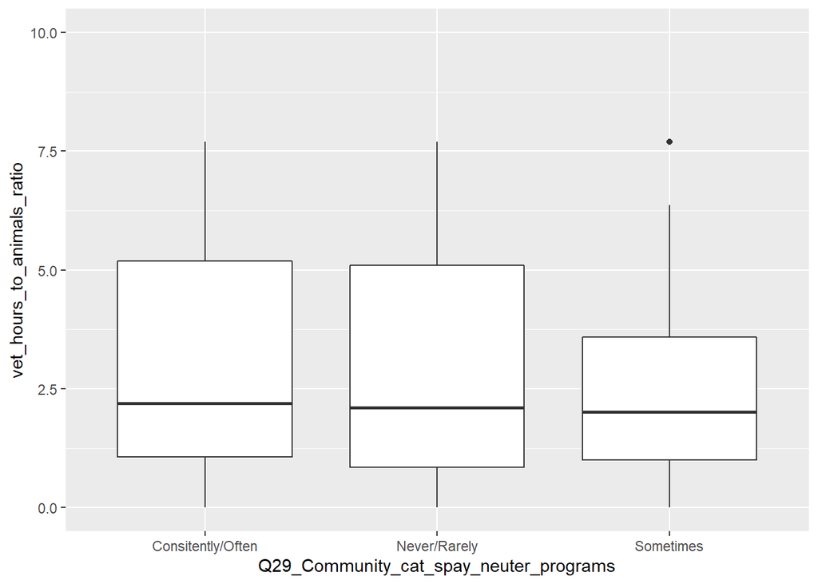

```
## Call:
## multinom(formula = model_formula, data = clean_Log_bm_shelters)
##
## Coefficients:
##              (Intercept) vet_hours_to_animals_ratio
## Never/Rarely  0.05166007                 -0.2648183
## Sometimes    -0.45021077                 -0.1210635
##
## Std. Errors:
##              (Intercept) vet_hours_to_animals_ratio
## Never/Rarely   0.1569700                 0.06073993
## Sometimes      0.1746539                 0.05517608
##
## Residual Deviance: 761.0569
## AIC: 769.0569
```

#### Agreement to Cat Sterilization Statement

```
##
## col_name            Gov Shelter Non-Profit WITH Non-Profit WO
##   Neither                    15              14            26
##   Somewhat agree             14              24            32
##   Somewhat disagree           5               5            11
##   Strongly agree             59              70            63
##   Strongly disagree          11               9            15
##
## col_name            Gov Shelter Non-Profit WITH Non-Profit WO
##   Neither            0.14423077      0.11475410    0.17687075
##   Somewhat agree     0.13461538      0.19672131    0.21768707
##   Somewhat disagree  0.04807692      0.04098361    0.07482993
##   Strongly agree     0.56730769      0.57377049    0.42857143
##   Strongly disagree  0.10576923      0.07377049    0.10204082
## # A tibble: 1 x 4
##   Service                                               P_Value Cramer_V Count
##   <chr>                                                   <dbl>    <dbl> <int>
## 1 Q41_Level_Of_Agreement_To_Cat_Sterilization_Statement   0.272    0.115   373
##
## col_name            Metro Non-Metro
##   Neither              43        12
##   Somewhat agree       56        14
##   Somewhat disagree    19         2
##   Strongly agree      158        34
##   Strongly disagree    31         4
##
## col_name                 Metro  Non-Metro
##   Neither           0.14006515 0.18181818
##   Somewhat agree    0.18241042 0.21212121
##   Somewhat disagree 0.06188925 0.03030303
##   Strongly agree    0.51465798 0.51515152
##   Strongly disagree 0.10097720 0.06060606
## # A tibble: 1 x 4
##   Service                                               P_Value Cramer_V Count
##   <chr>                                                   <dbl>    <dbl> <int>
## 1 Q41_Level_Of_Agreement_To_Cat_Sterilization_Statement   0.591   0.0867   373
##
## col_name            Greater 1M Less 1M
##   Neither                   31      20
##   Somewhat agree            42      26
```

[output cut: 105 more lines]

```
##                                     Somewhat agree     26  44
##                                     Somewhat disagree   6  15
##                                     Strongly agree     71 121
##                                     Strongly disagree  14  21
##                                                      Vet on Staff
## Q41_Level_Of_Agreement_To_Cat_Sterilization_Statement        No       Yes
##                                     Neither           0.3272727 0.6727273
##                                     Somewhat agree    0.3714286 0.6285714
##                                     Somewhat disagree 0.2857143 0.7142857
##                                     Strongly agree    0.3697917 0.6302083
##                                     Strongly disagree 0.4000000 0.6000000
## # A tibble: 1 x 4
##   Service                                               P_Value Cramer_V Count
##   <chr>                                                   <dbl>    <dbl> <int>
## 1 Q41_Level_Of_Agreement_To_Cat_Sterilization_Statement   0.892   0.0546   373
```

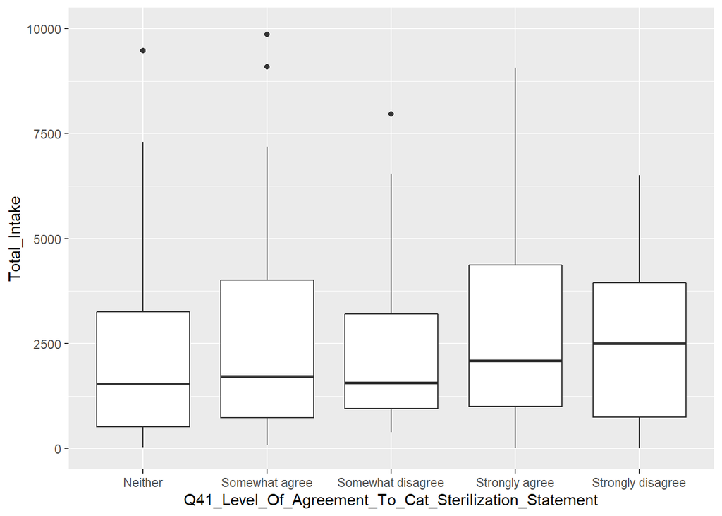

```
## Call:
## multinom(formula = model_formula, data = clean_Log_bm_shelters)
##
## Coefficients:
##                   (Intercept)  Total_Intake
## Somewhat agree      0.1641340  2.481591e-05
## Somewhat disagree  -1.0199545  1.856665e-05
## Strongly agree      1.1317522  3.747996e-05
## Strongly disagree  -0.4415027 -3.505777e-06
##
## Std. Errors:
##                   (Intercept) Total_Intake
## Somewhat agree    0.066033328 4.388170e-05
## Somewhat disagree 0.009788811 6.021397e-05
## Strongly agree    0.116897046 4.135864e-05
## Strongly disagree 0.019702048 5.266665e-05
##
## Residual Deviance: 985.4786
## AIC: 1001.479
```

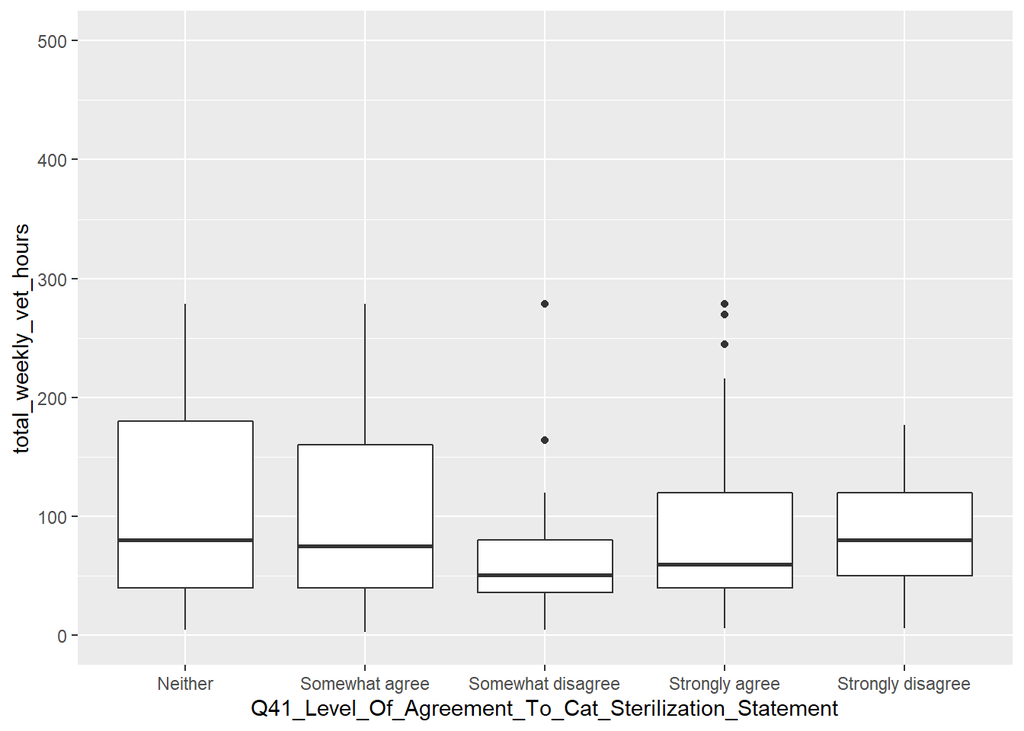

```
## Call:
## multinom(formula = model_formula, data = clean_Log_bm_shelters)
##
## Coefficients:
##                   (Intercept) total_weekly_vet_hours
## Somewhat agree      0.3490005           -0.001563262
## Somewhat disagree  -0.2561056           -0.006795895
## Strongly agree      1.5809099           -0.003792759
## Strongly disagree  -0.1639753           -0.003861679
##
## Std. Errors:
##                   (Intercept) total_weekly_vet_hours
## Somewhat agree      0.3628745            0.002535835
## Somewhat disagree   0.4792788            0.004319409
## Strongly agree      0.3064955            0.002176548
## Strongly disagree   0.4338994            0.003369637
##
## Residual Deviance: 630.1188
## AIC: 646.1188
```

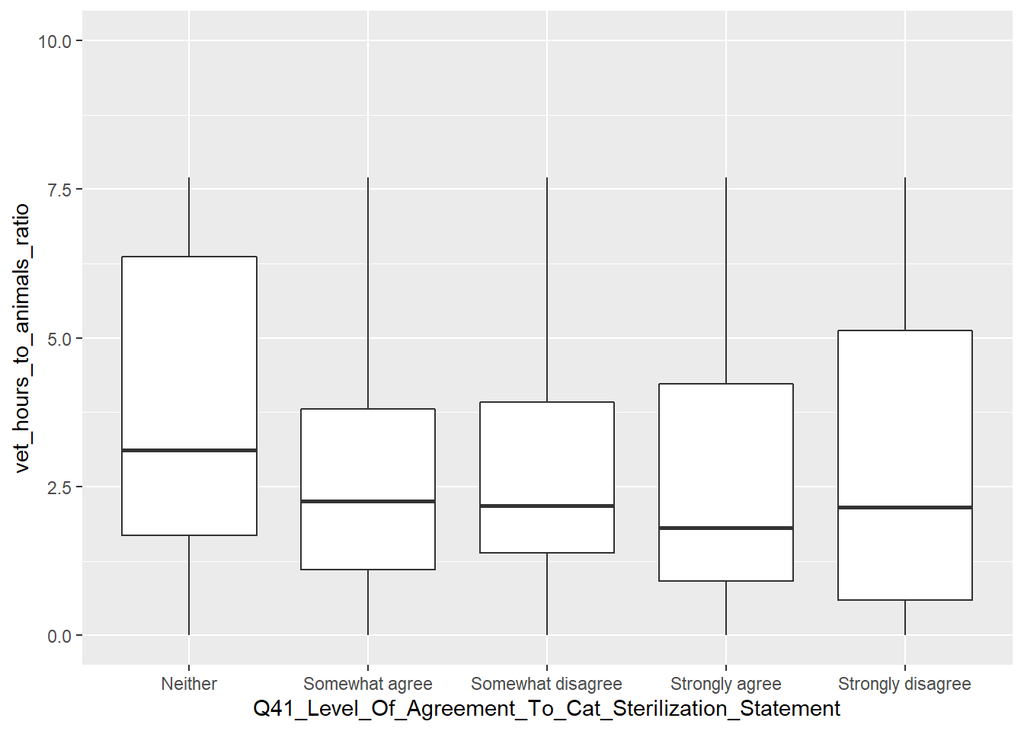

```
## Call:
## multinom(formula = model_formula, data = clean_Log_bm_shelters)
##
## Coefficients:
##                   (Intercept) vet_hours_to_animals_ratio
## Somewhat agree      0.4987458                -0.11845102
## Somewhat disagree  -0.9552209                -0.00295822
## Strongly agree      1.4934919                -0.11070287
## Strongly disagree  -0.2930925                -0.08211184
##
## Std. Errors:
##                   (Intercept) vet_hours_to_animals_ratio
## Somewhat agree      0.2401951                 0.07182308
## Somewhat disagree   0.3524762                 0.09455181
## Strongly agree      0.2075251                 0.05860255
## Strongly disagree   0.2899501                 0.08598389
##
## Residual Deviance: 976.6644
## AIC: 992.6644
```